# 1.Business problem:

● The Ultimate objective is to predict whether an Ola driver will be leaving the company or not based on different attributes.

# 2.Data load and basic non-graphical EDA

```python
from google.colab import drive
import pandas as pd
import numpy as np
import seaborn as sns
import matplotlib.pyplot as plt
from sklearn.preprocessing import StandardScaler
from sklearn.preprocessing import OneHotEncoder
from sklearn.model_selection import train_test_split
from sklearn.model_selection import GridSearchCV
from sklearn.preprocessing import StandardScaler
from sklearn.preprocessing import MinMaxScaler
import statsmodels.api as sm
from statsmodels.stats.outliers_influence import variance_inflation_factor
from statsmodels.compat import lzip
from sklearn.metrics import mean_absolute_error, mean_squared_error
from scipy.stats import zscore
from sklearn.preprocessing import OneHotEncoder
from sklearn.preprocessing import StandardScaler
from sklearn.linear_model import LogisticRegression
from sklearn.metrics import accuracy_score, precision_score, recall_score, f1_score
from sklearn.model_selection import train_test_split
from sklearn.pipeline import make_pipeline
from imblearn.over_sampling import SMOTE
from sklearn.metrics import classification_report
from sklearn.metrics import ConfusionMatrixDisplay
from sklearn.metrics import confusion_matrix
from sklearn.pipeline import Pipeline
from sklearn.compose import ColumnTransformer
from sklearn.tree import DecisionTreeClassifier
from sklearn.model_selection import RandomizedSearchCV, StratifiedKFold
from sklearn.ensemble import RandomForestClassifier
from xgboost import XGBClassifier
from sklearn.metrics import precision_recall_curve, auc
from sklearn.metrics import roc_curve, auc
```

```python
pd.set_option('display.max_columns', None)

drive.mount('/content/drive')

data = pd.read_csv('/content/drive/MyDrive/Scaler notes/Business case studies/Case-8 OLA - Ensemble Learning/ola_driver_scaler.csv', sep = ",")
data = data.drop(data.columns[0], axis=1)
data.head()
```

|  | MMM-YY | Driver_ID | Age | Gender | City | Education_Level | Income | Dateofjoining | LastWorkingDate | Joining Designation | Grade | Total Business Value | Quarterly Rating |
| --- | --- | --- | --- | --- | --- | --- | --- | --- | --- | --- | --- | --- | --- |
| 0 | 01/01/19 | 1 | 28.0 | 0.0 | C23 | 2 | 57387 | 24/12/18 | NaN | 1 | 1 | 2381060 | 2 |
| 1 | 02/01/19 | 1 | 28.0 | 0.0 | C23 | 2 | 57387 | 24/12/18 | NaN | 1 | 1 | -665480 | 2 |
| 2 | 03/01/19 | 1 | 28.0 | 0.0 | C23 | 2 | 57387 | 24/12/18 | 03/11/19 | 1 | 1 | 0 | 2 |
| 3 | 11/01/20 | 2 | 31.0 | 0.0 | C7 | 2 | 67016 | 11/06/20 | NaN | 2 | 2 | 0 | 1 |
| 4 | 12/01/20 | 2 | 31.0 | 0.0 | C7 | 2 | 67016 | 11/06/20 | NaN | 2 | 2 | 0 | 1 |

```python
data.info()
```

```
<class 'pandas.core.frame.DataFrame'>
RangeIndex: 19104 entries, 0 to 19103
Data columns (total 13 columns):
 #   Column                Non-Null Count  Dtype
---  ------                --------------  -----
 0   MMM-YY                19104 non-null  object
 1   Driver_ID             19104 non-null  int64
 2   Age                   19043 non-null  float64
 3   Gender                19052 non-null  float64
 4   City                  19104 non-null  object
 5   Education_Level       19104 non-null  int64
 6   Income                19104 non-null  int64
 7   Dateofjoining         19104 non-null  object
 8   LastWorkingDate       1616 non-null   object
 9   Joining Designation   19104 non-null  int64
 10  Grade                 19104 non-null  int64
 11  Total Business Value  19104 non-null  int64
 12  Quarterly Rating      19104 non-null  int64
dtypes: float64(2), int64(7), object(4)
memory usage: 1.9+ MB
```

```python
data.rename(columns ={'Joining Designation': 'Joining_Designation',
                      'Total Business Value': 'Total_Business_Value',
                      'Quarterly Rating': 'Quarterly_Rating'}, inplace = True)
```

```python
data.describe()
```

|  | Driver_ID | Age | Gender | Education_Level | Income | Joining_Designation | Grade | Total_Business_Value | Quarterly_Rating |
| --- | --- | --- | --- | --- | --- | --- | --- | --- | --- |
| count | 19104.000000 | 19043.000000 | 19052.000000 | 19104.000000 | 19104.000000 | 19104.000000 | 19104.000000 | 1.910400e+04 | 19104.000000 |
| mean | 1415.591133 | 34.668435 | 0.418749 | 1.021671 | 65652.025126 | 1.690536 | 2.252670 | 5.716621e+05 | 2.008899 |
| std | 810.705321 | 6.257912 | 0.493367 | 0.800167 | 30914.515344 | 0.836984 | 1.026512 | 1.128312e+06 | 1.009832 |
| min | 1.000000 | 21.000000 | 0.000000 | 0.000000 | 10747.000000 | 1.000000 | 1.000000 | -6.000000e+06 | 1.000000 |
| 25% | 710.000000 | 30.000000 | 0.000000 | 0.000000 | 42383.000000 | 1.000000 | 1.000000 | 0.000000e+00 | 1.000000 |
| 50% | 1417.000000 | 34.000000 | 0.000000 | 1.000000 | 60087.000000 | 1.000000 | 2.000000 | 2.500000e+05 | 2.000000 |
| 75% | 2137.000000 | 39.000000 | 1.000000 | 2.000000 | 83969.000000 | 2.000000 | 3.000000 | 6.997000e+05 | 3.000000 |
| max | 2788.000000 | 58.000000 | 1.000000 | 2.000000 | 188418.000000 | 5.000000 | 5.000000 | 3.374772e+07 | 4.000000 |

```python
data[data.Total_Business_Value < 0]
```

|  | MMM-YY | Driver_ID | Age | Gender | City | Education_Level | Income | Dateofjoining | LastWorkingDate | Joining_Designation | Grade | Total_Business_Value | Quarterly_Rating |
| --- | --- | --- | --- | --- | --- | --- | --- | --- | --- | --- | --- | --- | --- |
| 1 | 02/01/19 | 1 | 28.0 | 0.0 | C23 | 2 | 57387 | 24/12/18 | NaN | 1 | 1 | -665480 | 2 |
| 129 | 04/01/20 | 25 | 30.0 | 0.0 | C24 | 1 | 102077 | 30/10/17 | NaN | 1 | 3 | -414250 | 3 |
| 187 | 11/01/19 | 36 | 40.0 | 1.0 | C18 | 1 | 32865 | 07/01/19 | NaN | 2 | 2 | -19350 | 2 |
| 191 | 03/01/20 | 36 | 40.0 | 1.0 | C18 | 1 | 32865 | 07/01/19 | NaN | 2 | 2 | -50000 | 1 |
| 196 | 08/01/20 | 36 | 41.0 | 1.0 | C18 | 1 | 32865 | 07/01/19 | 29/07/20 | 2 | 2 | -325140 | 2 |
| ... | ... | ... | ... | ... | ... | ... | ... | ... | ... | ... | ... | ... | ... |
| 18578 | 04/01/20 | 2716 | 32.0 | 1.0 | C29 | 1 | 38744 | 16/06/19 | NaN | 1 | 1 | -101490 | 1 |
| 18687 | 08/01/20 | 2728 | 27.0 | 1.0 | C19 | 2 | 28318 | 03/11/20 | NaN | 1 | 1 | -1704230 | 1 |
| 18705 | 09/01/20 | 2729 | 34.0 | 0.0 | C10 | 0 | 107274 | 08/04/19 | NaN | 4 | 4 | -223820 | 2 |
| 18847 | 05/01/19 | 2751 | 31.0 | 0.0 | C17 | 2 | 53115 | 11/05/15 | NaN | 1 | 1 | -21790 | 2 |
| 18915 | 03/01/20 | 2758 | 33.0 | 0.0 | C26 | 1 | 69141 | 11/07/19 | 23/03/20 | 2 | 2 | -606530 | 1 |

149 rows × 13 columns

```python
data.describe(include = 'object')
```

|  | MMM-YY | City | Dateofjoining | LastWorkingDate |
| --- | --- | --- | --- | --- |
| count | 19104 | 19104 | 19104 | 1616 |
| unique | 24 | 29 | 869 | 493 |
| top | 01/01/19 | C20 | 23/07/15 | 29/07/20 |
| freq | 1022 | 1008 | 192 | 70 |

```python
data.shape
```

```
(19104, 13)
```

```python
data.drop_duplicates(inplace = True)
data.shape
```

```
(19104, 13)
```

```python
100*data.isna().sum()/data.shape[0]
```

|  | 0 |
| --- | --- |
| MMM-YY | 0.000000 |
| Driver_ID | 0.000000 |
| Age | 0.319305 |
| Gender | 0.272194 |
| City | 0.000000 |
| Education_Level | 0.000000 |
| Income | 0.000000 |
| Dateofjoining | 0.000000 |
| LastWorkingDate | 91.541039 |
| Joining_Designation | 0.000000 |
| Grade | 0.000000 |
| Total_Business_Value | 0.000000 |
| Quarterly_Rating | 0.000000 |

**dtype:** float64

## Imputing Age and Gender

```python
driver_unique_Ages = data.groupby('Driver_ID').Age.nunique().reset_index()
driver_unique_Ages[driver_unique_Ages.Age > 1]
```

|  | Driver_ID | Age |
| --- | --- | --- |
| 8 | 13 | 3 |
| 11 | 17 | 2 |
| 14 | 21 | 2 |
| 15 | 22 | 2 |
| 16 | 24 | 2 |
| ... | ... | ... |
| 2367 | 2772 | 2 |
| 2369 | 2774 | 2 |
| 2376 | 2784 | 2 |
| 2378 | 2786 | 2 |
| 2380 | 2788 | 2 |

1086 rows × 2 columns

```python
driver_unique_Ages[driver_unique_Ages.Age > 2]
```

|  | Driver_ID | Age |
| --- | --- | --- |
| 8 | 13 | 3 |
| 17 | 25 | 3 |
| 18 | 26 | 3 |
| 29 | 41 | 3 |
| 40 | 54 | 3 |
| ... | ... | ... |
| 2342 | 2740 | 3 |
| 2351 | 2753 | 3 |
| 2352 | 2754 | 3 |
| 2363 | 2766 | 3 |
| 2366 | 2771 | 3 |

276 rows × 2 columns

```python
driver_unique_Ages[driver_unique_Ages.Age > 3]
```

|  | Driver_ID | Age |
| --- | --- | --- |

```python
driver_unique_Gender = data.groupby('Driver_ID').Gender.nunique().reset_index()
driver_unique_Gender[driver_unique_Gender.Gender > 1]
```

|  | Driver_ID | Gender |
| --- | --- | --- |

```python
Drivers_with_missing_age_feature=data[data.Age.isnull()].Driver_ID
Drivers_with_age_feature=data[data.Age.notnull()].Driver_ID
set(Drivers_with_missing_age_feature).intersection(set(Drivers_with_age_feature))
```

```
{20,
 22,
 24,
 40,
 49,
 63,
 69,
 103,
 120,
 167,
 179,
 183,
 204,
 215,
 305,
 313,
 325,
 369,
 422,
 458,
 541,
 560,
 607,
 617,
 718,
 778,
 901,
 954,
 1050,
 1072,
 1247,
 1378,
 1421,
 1430,
 1462,
 1588,
 1611,
 1669,
 1720,
 1852,
 1909,
 1932,
 1936,
 2073,
 2168,
 2273,
 2348,
 2351,
 2460,
 2507,
 2569,
 2618,
 2690,
 2730,
 2738,
 2751,
 2774}
```

```python
data[data.Driver_ID == 20]
```

|  | MMM-YY | Driver_ID | Age | Gender | City | Education_Level | Income | Dateofjoining | LastWorkingDate | Joining_Designation | Grade | Total_Business_Value | Quarterly_Rating |
| --- | --- | --- | --- | --- | --- | --- | --- | --- | --- | --- | --- | --- | --- |
| 68 | 10/01/19 | 20 | 26.0 | 1.0 | C19 | 0 | 40342 | 25/10/19 | NaN | 3 | 3 | 0 | 1 |
| 69 | 11/01/19 | 20 | 26.0 | 1.0 | C19 | 0 | 40342 | 25/10/19 | NaN | 3 | 3 | 0 | 1 |
| 70 | 12/01/19 | 20 | 26.0 | 1.0 | C19 | 0 | 40342 | 25/10/19 | NaN | 3 | 3 | 0 | 1 |
| 71 | 01/01/20 | 20 | 26.0 | 1.0 | C19 | 0 | 40342 | 25/10/19 | NaN | 3 | 3 | 0 | 1 |
| 72 | 02/01/20 | 20 | NaN | 1.0 | C19 | 0 | 40342 | 25/10/19 | NaN | 3 | 3 | 0 | 1 |
| 73 | 03/01/20 | 20 | 26.0 | 1.0 | C19 | 0 | 40342 | 25/10/19 | 03/01/20 | 3 | 3 | 0 | 1 |

```python
Drivers_with_missing_Gender_feature=data[data.Gender.isnull()].Driver_ID
Drivers_with_Gender_feature=data[data.Gender.notnull()].Driver_ID
set(Drivers_with_missing_Gender_feature).intersection(set(Drivers_with_Gender_feature))
```

```
{43,
 49,
 68,
 116,
 119,
 225,
 296,
 354,
 365,
 407,
 439,
 446,
 489,
 516,
 541,
 611,
 640,
 709,
 793,
 888,
 951,
 1004,
 1023,
 1028,
 1143,
 1156,
 1205,
 1312,
 1407,
 1452,
 1508,
 1621,
 1804,
 1877,
 1936,
 2057,
 2073,
 2093,
 2215,
 2228,
 2478,
 2517,
 2607,
 2693,
 2716,
 2728,
 2732,
 2738,
 2760,
 2765,
 2774}
```

```python
data[data.Driver_ID == 43]
```

|  | MMM-YY | Driver_ID | Age | Gender | City | Education_Level | Income | Dateofjoining | LastWorkingDate | Joining_Designation | Grade | Total_Business_Value | Quarterly_Rating |
| --- | --- | --- | --- | --- | --- | --- | --- | --- | --- | --- | --- | --- | --- |
| 239 | 01/01/19 | 43 | 27.0 | 1.0 | C15 | 0 | 12906 | 13/07/18 | NaN | 1 | 1 | 359890 | 1 |
| 240 | 02/01/19 | 43 | 27.0 | NaN | C15 | 0 | 12906 | 13/07/18 | 20/02/19 | 1 | 1 | 0 | 1 |

```python
data.Driver_ID.nunique()
```

```
2381
```

```python
driver_Age_mapping = data.groupby('Driver_ID').Age.min().reset_index()
driver_Age_mapping.shape
```

```
(2381, 2)
```

```python
driver_Age_mapping[driver_Age_mapping.Age.isna()]
```

|  | Driver_ID | Age |
| --- | --- | --- |

```python
driver_Age_mapping.rename(columns = {'Age': 'Age_at_joining'}, inplace = True)
driver_Age_mapping.head()
```

|  | Driver_ID | Age_at_joining |
| --- | --- | --- |
| 0 | 1 | 28.0 |
| 1 | 2 | 31.0 |
| 2 | 4 | 43.0 |
| 3 | 5 | 29.0 |
| 4 | 6 | 31.0 |

```python
set(Drivers_with_missing_age_feature).difference(set(Drivers_with_age_feature))
```

```
set()
```

```python
driver_Gender_mapping = data.groupby('Driver_ID').Gender.max().reset_index()
driver_Gender_mapping.shape
```

```
(2381, 2)
```

```python
driver_Gender_mapping[driver_Gender_mapping.Gender.isna()]
```

|  | Driver_ID | Gender |
| --- | --- | --- |

```python
set(Drivers_with_missing_Gender_feature).difference(set(Drivers_with_Gender_feature))
```

```
set()
```

```python
data.head()
```

|  | MMM-YY | Driver_ID | Age | Gender | City | Education_Level | Income | Dateofjoining | LastWorkingDate | Joining_Designation | Grade | Total_Business_Value | Quarterly_Rating |
| --- | --- | --- | --- | --- | --- | --- | --- | --- | --- | --- | --- | --- | --- |
| 0 | 01/01/19 | 1 | 28.0 | 0.0 | C23 | 2 | 57387 | 24/12/18 | NaN | 1 | 1 | 2381060 | 2 |
| 1 | 02/01/19 | 1 | 28.0 | 0.0 | C23 | 2 | 57387 | 24/12/18 | NaN | 1 | 1 | -665480 | 2 |
| 2 | 03/01/19 | 1 | 28.0 | 0.0 | C23 | 2 | 57387 | 24/12/18 | 03/11/19 | 1 | 1 | 0 | 2 |
| 3 | 11/01/20 | 2 | 31.0 | 0.0 | C7 | 2 | 67016 | 11/06/20 | NaN | 2 | 2 | 0 | 1 |
| 4 | 12/01/20 | 2 | 31.0 | 0.0 | C7 | 2 | 67016 | 11/06/20 | NaN | 2 | 2 | 0 | 1 |

```python
driver_Age_mapping.head()
```

|  | Driver_ID | Age_at_joining |
| --- | --- | --- |
| 0 | 1 | 28.0 |
| 1 | 2 | 31.0 |
| 2 | 4 | 43.0 |
| 3 | 5 | 29.0 |
| 4 | 6 | 31.0 |

```python
data = data.merge(driver_Age_mapping, on = 'Driver_ID', how = 'left')
data.head()
```

|  | MMM-YY | Driver_ID | Age | Gender | City | Education_Level | Income | Dateofjoining | LastWorkingDate | Joining_Designation | Grade | Total_Business_Value | Quarterly_Rating | Age_at_joining |
| --- | --- | --- | --- | --- | --- | --- | --- | --- | --- | --- | --- | --- | --- | --- |
| 0 | 01/01/19 | 1 | 28.0 | 0.0 | C23 | 2 | 57387 | 24/12/18 | NaN | 1 | 1 | 2381060 | 2 | 28.0 |
| 1 | 02/01/19 | 1 | 28.0 | 0.0 | C23 | 2 | 57387 | 24/12/18 | NaN | 1 | 1 | -665480 | 2 | 28.0 |
| 2 | 03/01/19 | 1 | 28.0 | 0.0 | C23 | 2 | 57387 | 24/12/18 | 03/11/19 | 1 | 1 | 0 | 2 | 28.0 |
| 3 | 11/01/20 | 2 | 31.0 | 0.0 | C7 | 2 | 67016 | 11/06/20 | NaN | 2 | 2 | 0 | 1 | 31.0 |
| 4 | 12/01/20 | 2 | 31.0 | 0.0 | C7 | 2 | 67016 | 11/06/20 | NaN | 2 | 2 | 0 | 1 | 31.0 |

```python
data.drop(columns = ['Gender'], inplace = True)
data = data.merge(driver_Gender_mapping, on = 'Driver_ID', how = 'left')
data.head()
```

|  | MMM-YY | Driver_ID | Age | City | Education_Level | Income | Dateofjoining | LastWorkingDate | Joining_Designation | Grade | Total_Business_Value | Quarterly_Rating | Age_at_joining | Gender |
| --- | --- | --- | --- | --- | --- | --- | --- | --- | --- | --- | --- | --- | --- | --- |
| 0 | 01/01/19 | 1 | 28.0 | C23 | 2 | 57387 | 24/12/18 | NaN | 1 | 1 | 2381060 | 2 | 28.0 | 0.0 |
| 1 | 02/01/19 | 1 | 28.0 | C23 | 2 | 57387 | 24/12/18 | NaN | 1 | 1 | -665480 | 2 | 28.0 | 0.0 |
| 2 | 03/01/19 | 1 | 28.0 | C23 | 2 | 57387 | 24/12/18 | 03/11/19 | 1 | 1 | 0 | 2 | 28.0 | 0.0 |
| 3 | 11/01/20 | 2 | 31.0 | C7 | 2 | 67016 | 11/06/20 | NaN | 2 | 2 | 0 | 1 | 31.0 | 0.0 |
| 4 | 12/01/20 | 2 | 31.0 | C7 | 2 | 67016 | 11/06/20 | NaN | 2 | 2 | 0 | 1 | 31.0 | 0.0 |

```python
100*data.isna().sum()/data.shape[0]
```

|  | 0 |
| --- | --- |
| MMM-YY | 0.000000 |
| Driver_ID | 0.000000 |
| Age | 0.319305 |
| City | 0.000000 |
| Education_Level | 0.000000 |
| Income | 0.000000 |
| Dateofjoining | 0.000000 |
| LastWorkingDate | 91.541039 |
| Joining_Designation | 0.000000 |
| Grade | 0.000000 |
| Total_Business_Value | 0.000000 |
| Quarterly_Rating | 0.000000 |
| Age_at_joining | 0.000000 |
| Gender | 0.000000 |

**dtype:** float64

```python
data.info()
```

```
<class 'pandas.core.frame.DataFrame'>
RangeIndex: 19104 entries, 0 to 19103
Data columns (total 14 columns):
 #   Column                Non-Null Count  Dtype
---  ------                --------------  -----
 0   MMM-YY                19104 non-null  object
 1   Driver_ID             19104 non-null  int64
 2   Age                   19043 non-null  float64
 3   City                  19104 non-null  object
 4   Education_Level       19104 non-null  int64
 5   Income                19104 non-null  int64
 6   Dateofjoining         19104 non-null  object
 7   LastWorkingDate       1616 non-null   object
 8   Joining_Designation   19104 non-null  int64
 9   Grade                 19104 non-null  int64
 10  Total_Business_Value  19104 non-null  int64
 11  Quarterly_Rating      19104 non-null  int64
 12  Age_at_joining        19104 non-null  float64
 13  Gender                19104 non-null  float64
dtypes: float64(3), int64(7), object(4)
memory usage: 2.0+ MB
```

## Data Quality Check

```python
data.head()
```

|  | MMM-YY | Driver_ID | Age | City | Education_Level | Income | Dateofjoining | LastWorkingDate | Joining_Designation | Grade | Total_Business_Value | Quarterly_Rating | Age_at_joining | Gender |
| --- | --- | --- | --- | --- | --- | --- | --- | --- | --- | --- | --- | --- | --- | --- |
| 0 | 01/01/19 | 1 | 28.0 | C23 | 2 | 57387 | 24/12/18 | NaN | 1 | 1 | 2381060 | 2 | 28.0 | 0.0 |
| 1 | 02/01/19 | 1 | 28.0 | C23 | 2 | 57387 | 24/12/18 | NaN | 1 | 1 | -665480 | 2 | 28.0 | 0.0 |
| 2 | 03/01/19 | 1 | 28.0 | C23 | 2 | 57387 | 24/12/18 | 03/11/19 | 1 | 1 | 0 | 2 | 28.0 | 0.0 |
| 3 | 11/01/20 | 2 | 31.0 | C7 | 2 | 67016 | 11/06/20 | NaN | 2 | 2 | 0 | 1 | 31.0 | 0.0 |
| 4 | 12/01/20 | 2 | 31.0 | C7 | 2 | 67016 | 11/06/20 | NaN | 2 | 2 | 0 | 1 | 31.0 | 0.0 |

```python
data_ql = data.groupby('Driver_ID')[['City', 'Education_Level', 'Income', 'Dateofjoining', 'Joining_Designation', 'Grade', 'Quarterly_Rating']].nunique().reset_index()
```

```python
data_ql.head()
```

|  | Driver_ID | City | Education_Level | Income | Dateofjoining | Joining_Designation | Grade | Quarterly_Rating |
| --- | --- | --- | --- | --- | --- | --- | --- | --- |
| 0 | 1 | 1 | 1 | 1 | 1 | 1 | 1 | 1 |
| 1 | 2 | 1 | 1 | 1 | 1 | 1 | 1 | 1 |
| 2 | 4 | 1 | 1 | 1 | 1 | 1 | 1 | 1 |
| 3 | 5 | 1 | 1 | 1 | 1 | 1 | 1 | 1 |
| 4 | 6 | 1 | 1 | 1 | 1 | 1 | 1 | 2 |

```python
for col in data_ql.columns[1:]:
  print(data_ql[col].value_counts())
  print('*******************************')
```

```
City
1    2381
Name: count, dtype: int64
Education_Level
1    2381
Name: count, dtype: int64
Income
1    2337
2      44
Name: count, dtype: int64
Dateofjoining
1    2381
Name: count, dtype: int64
Joining_Designation
1    2381
Name: count, dtype: int64
Grade
1    2337
2      44
Name: count, dtype: int64
Quarterly_Rating
1    1277
2     657
3     356
4      91
Name: count, dtype: int64
```

Observations:

Quarterly_Rating, Income and Grade varies for same Driver_ID.

```python
print(set(data_ql[data_ql.Grade > 1].Driver_ID).difference(set(data_ql[data_ql.Income > 1].Driver_ID)))
print(set(data_ql[data_ql.Income > 1].Driver_ID).difference(set(data_ql[data_ql.Grade > 1].Driver_ID)))
```

```
set()
set()
```

```python
data[data.Driver_ID.isin(list(data_ql[data_ql.Income > 1].Driver_ID))].head(50)
```

|  | MMM-YY | Driver_ID | Age | City | Education_Level | Income | Dateofjoining | LastWorkingDate | Joining_Designation | Grade | Total_Business_Value | Quarterly_Rating | Age_at_joining | Gender |
| --- | --- | --- | --- | --- | --- | --- | --- | --- | --- | --- | --- | --- | --- | --- |
| 138 | 01/01/19 | 26 | 41.0 | C14 | 2 | 121529 | 05/07/18 | NaN | 1 | 3 | 243110 | 4 | 41.0 | 0.0 |
| 139 | 02/01/19 | 26 | 41.0 | C14 | 2 | 121529 | 05/07/18 | NaN | 1 | 3 | 646330 | 4 | 41.0 | 0.0 |
| 140 | 03/01/19 | 26 | 41.0 | C14 | 2 | 121529 | 05/07/18 | NaN | 1 | 3 | 17651940 | 4 | 41.0 | 0.0 |
| 141 | 04/01/19 | 26 | 41.0 | C14 | 2 | 121529 | 05/07/18 | NaN | 1 | 3 | 242510 | 4 | 41.0 | 0.0 |
| 142 | 05/01/19 | 26 | 41.0 | C14 | 2 | 121529 | 05/07/18 | NaN | 1 | 3 | 1098080 | 4 | 41.0 | 0.0 |
| 143 | 06/01/19 | 26 | 41.0 | C14 | 2 | 121529 | 05/07/18 | NaN | 1 | 3 | 1212720 | 4 | 41.0 | 0.0 |
| 144 | 07/01/19 | 26 | 41.0 | C14 | 2 | 121529 | 05/07/18 | NaN | 1 | 3 | 2695910 | 4 | 41.0 | 0.0 |
| 145 | 08/01/19 | 26 | 41.0 | C14 | 2 | 121529 | 05/07/18 | NaN | 1 | 3 | 494710 | 4 | 41.0 | 0.0 |
| 146 | 09/01/19 | 26 | 42.0 | C14 | 2 | 121529 | 05/07/18 | NaN | 1 | 3 | 986540 | 4 | 41.0 | 0.0 |
| 147 | 10/01/19 | 26 | 42.0 | C14 | 2 | 121529 | 05/07/18 | NaN | 1 | 3 | 9950710 | 4 | 41.0 | 0.0 |
| 148 | 11/01/19 | 26 | 42.0 | C14 | 2 | 121529 | 05/07/18 | NaN | 1 | 3 | 13097320 | 4 | 41.0 | 0.0 |
| 149 | 12/01/19 | 26 | 42.0 | C14 | 2 | 121529 | 05/07/18 | NaN | 1 | 3 | 1086370 | 4 | 41.0 | 0.0 |
| 150 | 01/01/20 | 26 | 42.0 | C14 | 2 | 121529 | 05/07/18 | NaN | 1 | 3 | 732410 | 2 | 41.0 | 0.0 |
| 151 | 02/01/20 | 26 | 42.0 | C14 | 2 | 121529 | 05/07/18 | NaN | 1 | 3 | 1511840 | 2 | 41.0 | 0.0 |
| 152 | 03/01/20 | 26 | 42.0 | C14 | 2 | 132577 | 05/07/18 | NaN | 1 | 4 | 9226690 | 4 | 41.0 | 0.0 |
| 153 | 04/01/20 | 26 | 42.0 | C14 | 2 | 132577 | 05/07/18 | NaN | 1 | 4 | 1940050 | 2 | 41.0 | 0.0 |
| 154 | 05/01/20 | 26 | 42.0 | C14 | 2 | 132577 | 05/07/18 | NaN | 1 | 4 | 970030 | 2 | 41.0 | 0.0 |
| 155 | 06/01/20 | 26 | 42.0 | C14 | 2 | 132577 | 05/07/18 | NaN | 1 | 4 | 0 | 2 | 41.0 | 0.0 |
| 156 | 07/01/20 | 26 | 42.0 | C14 | 2 | 132577 | 05/07/18 | NaN | 1 | 4 | 153590 | 2 | 41.0 | 0.0 |
| 157 | 08/01/20 | 26 | 42.0 | C14 | 2 | 132577 | 05/07/18 | NaN | 1 | 4 | 1710410 | 2 | 41.0 | 0.0 |
| 158 | 09/01/20 | 26 | 43.0 | C14 | 2 | 132577 | 05/07/18 | NaN | 1 | 4 | 440550 | 2 | 41.0 | 0.0 |
| 159 | 10/01/20 | 26 | 43.0 | C14 | 2 | 132577 | 05/07/18 | NaN | 1 | 4 | 744590 | 2 | 41.0 | 0.0 |
| 160 | 11/01/20 | 26 | 43.0 | C14 | 2 | 132577 | 05/07/18 | NaN | 1 | 4 | 1578270 | 2 | 41.0 | 0.0 |
| 161 | 12/01/20 | 26 | 43.0 | C14 | 2 | 132577 | 05/07/18 | NaN | 1 | 4 | 1453220 | 2 | 41.0 | 0.0 |
| 288 | 07/01/19 | 54 | 33.0 | C29 | 1 | 117993 | 07/11/19 | NaN | 4 | 4 | 0 | 2 | 33.0 | 0.0 |
| 289 | 08/01/19 | 54 | 33.0 | C29 | 1 | 117993 | 07/11/19 | NaN | 4 | 4 | 0 | 2 | 33.0 | 0.0 |
| 290 | 09/01/19 | 54 | 33.0 | C29 | 1 | 117993 | 07/11/19 | NaN | 4 | 4 | 2000000 | 2 | 33.0 | 0.0 |
| 291 | 10/01/19 | 54 | 33.0 | C29 | 1 | 117993 | 07/11/19 | NaN | 4 | 4 | 0 | 3 | 33.0 | 0.0 |
| 292 | 11/01/19 | 54 | 33.0 | C29 | 1 | 117993 | 07/11/19 | NaN | 4 | 4 | 1950000 | 3 | 33.0 | 0.0 |
| 293 | 12/01/19 | 54 | 34.0 | C29 | 1 | 117993 | 07/11/19 | NaN | 4 | 4 | 1455010 | 3 | 33.0 | 0.0 |
| 294 | 01/01/20 | 54 | 34.0 | C29 | 1 | 117993 | 07/11/19 | NaN | 4 | 4 | 3398000 | 4 | 33.0 | 0.0 |
| 295 | 02/01/20 | 54 | 34.0 | C29 | 1 | 117993 | 07/11/19 | NaN | 4 | 4 | 6062470 | 4 | 33.0 | 0.0 |
| 296 | 03/01/20 | 54 | 34.0 | C29 | 1 | 117993 | 07/11/19 | NaN | 4 | 4 | 14620880 | 4 | 33.0 | 0.0 |
| 297 | 04/01/20 | 54 | 34.0 | C29 | 1 | 117993 | 07/11/19 | NaN | 4 | 4 | 0 | 2 | 33.0 | 0.0 |
| 298 | 05/01/20 | 54 | 34.0 | C29 | 1 | 117993 | 07/11/19 | NaN | 4 | 4 | 1380000 | 2 | 33.0 | 0.0 |
| 299 | 06/01/20 | 54 | 34.0 | C29 | 1 | 127826 | 07/11/19 | NaN | 4 | 5 | 1449260 | 3 | 33.0 | 0.0 |
| 300 | 07/01/20 | 54 | 34.0 | C29 | 1 | 127826 | 07/11/19 | NaN | 4 | 5 | 193240 | 1 | 33.0 | 0.0 |
| 301 | 08/01/20 | 54 | 34.0 | C29 | 1 | 127826 | 07/11/19 | NaN | 4 | 5 | 350000 | 1 | 33.0 | 0.0 |
| 302 | 09/01/20 | 54 | 34.0 | C29 | 1 | 127826 | 07/11/19 | NaN | 4 | 5 | 0 | 1 | 33.0 | 0.0 |
| 303 | 10/01/20 | 54 | 34.0 | C29 | 1 | 127826 | 07/11/19 | NaN | 4 | 5 | 0 | 1 | 33.0 | 0.0 |
| 304 | 11/01/20 | 54 | 34.0 | C29 | 1 | 127826 | 07/11/19 | NaN | 4 | 5 | 0 | 1 | 33.0 | 0.0 |
| 305 | 12/01/20 | 54 | 35.0 | C29 | 1 | 127826 | 07/11/19 | NaN | 4 | 5 | 964430 | 1 | 33.0 | 0.0 |
| 358 | 01/01/19 | 60 | 46.0 | C20 | 0 | 82126 | 17/09/16 | NaN | 1 | 3 | 913700 | 4 | 46.0 | 1.0 |
| 359 | 02/01/19 | 60 | 46.0 | C20 | 0 | 82126 | 17/09/16 | NaN | 1 | 3 | 1435000 | 4 | 46.0 | 1.0 |
| 360 | 03/01/19 | 60 | 46.0 | C20 | 0 | 82126 | 17/09/16 | NaN | 1 | 3 | 7799990 | 4 | 46.0 | 1.0 |
| 361 | 04/01/19 | 60 | 46.0 | C20 | 0 | 82126 | 17/09/16 | NaN | 1 | 3 | 999000 | 3 | 46.0 | 1.0 |
| 362 | 05/01/19 | 60 | 46.0 | C20 | 0 | 82126 | 17/09/16 | NaN | 1 | 3 | 250000 | 3 | 46.0 | 1.0 |
| 363 | 06/01/19 | 60 | 46.0 | C20 | 0 | 82126 | 17/09/16 | NaN | 1 | 3 | 500000 | 3 | 46.0 | 1.0 |
| 364 | 07/01/19 | 60 | 46.0 | C20 | 0 | 82126 | 17/09/16 | NaN | 1 | 3 | 750000 | 3 | 46.0 | 1.0 |
| 365 | 08/01/19 | 60 | 46.0 | C20 | 0 | 82126 | 17/09/16 | NaN | 1 | 3 | 2000000 | 3 | 46.0 | 1.0 |

```python
data[data.Driver_ID == 26]
```

|  | MMM-YY | Driver_ID | Age | City | Education_Level | Income | Dateofjoining | LastWorkingDate | Joining_Designation | Grade | Total_Business_Value | Quarterly_Rating | Age_at_joining | Gender |
| --- | --- | --- | --- | --- | --- | --- | --- | --- | --- | --- | --- | --- | --- | --- |
| 138 | 01/01/19 | 26 | 41.0 | C14 | 2 | 121529 | 05/07/18 | NaN | 1 | 3 | 243110 | 4 | 41.0 | 0.0 |
| 139 | 02/01/19 | 26 | 41.0 | C14 | 2 | 121529 | 05/07/18 | NaN | 1 | 3 | 646330 | 4 | 41.0 | 0.0 |
| 140 | 03/01/19 | 26 | 41.0 | C14 | 2 | 121529 | 05/07/18 | NaN | 1 | 3 | 17651940 | 4 | 41.0 | 0.0 |
| 141 | 04/01/19 | 26 | 41.0 | C14 | 2 | 121529 | 05/07/18 | NaN | 1 | 3 | 242510 | 4 | 41.0 | 0.0 |
| 142 | 05/01/19 | 26 | 41.0 | C14 | 2 | 121529 | 05/07/18 | NaN | 1 | 3 | 1098080 | 4 | 41.0 | 0.0 |
| 143 | 06/01/19 | 26 | 41.0 | C14 | 2 | 121529 | 05/07/18 | NaN | 1 | 3 | 1212720 | 4 | 41.0 | 0.0 |
| 144 | 07/01/19 | 26 | 41.0 | C14 | 2 | 121529 | 05/07/18 | NaN | 1 | 3 | 2695910 | 4 | 41.0 | 0.0 |
| 145 | 08/01/19 | 26 | 41.0 | C14 | 2 | 121529 | 05/07/18 | NaN | 1 | 3 | 494710 | 4 | 41.0 | 0.0 |
| 146 | 09/01/19 | 26 | 42.0 | C14 | 2 | 121529 | 05/07/18 | NaN | 1 | 3 | 986540 | 4 | 41.0 | 0.0 |
| 147 | 10/01/19 | 26 | 42.0 | C14 | 2 | 121529 | 05/07/18 | NaN | 1 | 3 | 9950710 | 4 | 41.0 | 0.0 |
| 148 | 11/01/19 | 26 | 42.0 | C14 | 2 | 121529 | 05/07/18 | NaN | 1 | 3 | 13097320 | 4 | 41.0 | 0.0 |
| 149 | 12/01/19 | 26 | 42.0 | C14 | 2 | 121529 | 05/07/18 | NaN | 1 | 3 | 1086370 | 4 | 41.0 | 0.0 |
| 150 | 01/01/20 | 26 | 42.0 | C14 | 2 | 121529 | 05/07/18 | NaN | 1 | 3 | 732410 | 2 | 41.0 | 0.0 |
| 151 | 02/01/20 | 26 | 42.0 | C14 | 2 | 121529 | 05/07/18 | NaN | 1 | 3 | 1511840 | 2 | 41.0 | 0.0 |
| 152 | 03/01/20 | 26 | 42.0 | C14 | 2 | 132577 | 05/07/18 | NaN | 1 | 4 | 9226690 | 4 | 41.0 | 0.0 |
| 153 | 04/01/20 | 26 | 42.0 | C14 | 2 | 132577 | 05/07/18 | NaN | 1 | 4 | 1940050 | 2 | 41.0 | 0.0 |
| 154 | 05/01/20 | 26 | 42.0 | C14 | 2 | 132577 | 05/07/18 | NaN | 1 | 4 | 970030 | 2 | 41.0 | 0.0 |
| 155 | 06/01/20 | 26 | 42.0 | C14 | 2 | 132577 | 05/07/18 | NaN | 1 | 4 | 0 | 2 | 41.0 | 0.0 |
| 156 | 07/01/20 | 26 | 42.0 | C14 | 2 | 132577 | 05/07/18 | NaN | 1 | 4 | 153590 | 2 | 41.0 | 0.0 |
| 157 | 08/01/20 | 26 | 42.0 | C14 | 2 | 132577 | 05/07/18 | NaN | 1 | 4 | 1710410 | 2 | 41.0 | 0.0 |
| 158 | 09/01/20 | 26 | 43.0 | C14 | 2 | 132577 | 05/07/18 | NaN | 1 | 4 | 440550 | 2 | 41.0 | 0.0 |
| 159 | 10/01/20 | 26 | 43.0 | C14 | 2 | 132577 | 05/07/18 | NaN | 1 | 4 | 744590 | 2 | 41.0 | 0.0 |
| 160 | 11/01/20 | 26 | 43.0 | C14 | 2 | 132577 | 05/07/18 | NaN | 1 | 4 | 1578270 | 2 | 41.0 | 0.0 |
| 161 | 12/01/20 | 26 | 43.0 | C14 | 2 | 132577 | 05/07/18 | NaN | 1 | 4 | 1453220 | 2 | 41.0 | 0.0 |

```python
data[data.Driver_ID == 54]
```

|  | MMM-YY | Driver_ID | Age | City | Education_Level | Income | Dateofjoining | LastWorkingDate | Joining_Designation | Grade | Total_Business_Value | Quarterly_Rating | Age_at_joining | Gender |
| --- | --- | --- | --- | --- | --- | --- | --- | --- | --- | --- | --- | --- | --- | --- |
| 288 | 07/01/19 | 54 | 33.0 | C29 | 1 | 117993 | 07/11/19 | NaN | 4 | 4 | 0 | 2 | 33.0 | 0.0 |
| 289 | 08/01/19 | 54 | 33.0 | C29 | 1 | 117993 | 07/11/19 | NaN | 4 | 4 | 0 | 2 | 33.0 | 0.0 |
| 290 | 09/01/19 | 54 | 33.0 | C29 | 1 | 117993 | 07/11/19 | NaN | 4 | 4 | 2000000 | 2 | 33.0 | 0.0 |
| 291 | 10/01/19 | 54 | 33.0 | C29 | 1 | 117993 | 07/11/19 | NaN | 4 | 4 | 0 | 3 | 33.0 | 0.0 |
| 292 | 11/01/19 | 54 | 33.0 | C29 | 1 | 117993 | 07/11/19 | NaN | 4 | 4 | 1950000 | 3 | 33.0 | 0.0 |
| 293 | 12/01/19 | 54 | 34.0 | C29 | 1 | 117993 | 07/11/19 | NaN | 4 | 4 | 1455010 | 3 | 33.0 | 0.0 |
| 294 | 01/01/20 | 54 | 34.0 | C29 | 1 | 117993 | 07/11/19 | NaN | 4 | 4 | 3398000 | 4 | 33.0 | 0.0 |
| 295 | 02/01/20 | 54 | 34.0 | C29 | 1 | 117993 | 07/11/19 | NaN | 4 | 4 | 6062470 | 4 | 33.0 | 0.0 |
| 296 | 03/01/20 | 54 | 34.0 | C29 | 1 | 117993 | 07/11/19 | NaN | 4 | 4 | 14620880 | 4 | 33.0 | 0.0 |
| 297 | 04/01/20 | 54 | 34.0 | C29 | 1 | 117993 | 07/11/19 | NaN | 4 | 4 | 0 | 2 | 33.0 | 0.0 |
| 298 | 05/01/20 | 54 | 34.0 | C29 | 1 | 117993 | 07/11/19 | NaN | 4 | 4 | 1380000 | 2 | 33.0 | 0.0 |
| 299 | 06/01/20 | 54 | 34.0 | C29 | 1 | 127826 | 07/11/19 | NaN | 4 | 5 | 1449260 | 3 | 33.0 | 0.0 |
| 300 | 07/01/20 | 54 | 34.0 | C29 | 1 | 127826 | 07/11/19 | NaN | 4 | 5 | 193240 | 1 | 33.0 | 0.0 |
| 301 | 08/01/20 | 54 | 34.0 | C29 | 1 | 127826 | 07/11/19 | NaN | 4 | 5 | 350000 | 1 | 33.0 | 0.0 |
| 302 | 09/01/20 | 54 | 34.0 | C29 | 1 | 127826 | 07/11/19 | NaN | 4 | 5 | 0 | 1 | 33.0 | 0.0 |
| 303 | 10/01/20 | 54 | 34.0 | C29 | 1 | 127826 | 07/11/19 | NaN | 4 | 5 | 0 | 1 | 33.0 | 0.0 |
| 304 | 11/01/20 | 54 | 34.0 | C29 | 1 | 127826 | 07/11/19 | NaN | 4 | 5 | 0 | 1 | 33.0 | 0.0 |
| 305 | 12/01/20 | 54 | 35.0 | C29 | 1 | 127826 | 07/11/19 | NaN | 4 | 5 | 964430 | 1 | 33.0 | 0.0 |

```python
data[data.Driver_ID == 60]
```

|  | MMM-YY | Driver_ID | Age | City | Education_Level | Income | Dateofjoining | LastWorkingDate | Joining_Designation | Grade | Total_Business_Value | Quarterly_Rating | Age_at_joining | Gender |
| --- | --- | --- | --- | --- | --- | --- | --- | --- | --- | --- | --- | --- | --- | --- |
| 358 | 01/01/19 | 60 | 46.0 | C20 | 0 | 82126 | 17/09/16 | NaN | 1 | 3 | 913700 | 4 | 46.0 | 1.0 |
| 359 | 02/01/19 | 60 | 46.0 | C20 | 0 | 82126 | 17/09/16 | NaN | 1 | 3 | 1435000 | 4 | 46.0 | 1.0 |
| 360 | 03/01/19 | 60 | 46.0 | C20 | 0 | 82126 | 17/09/16 | NaN | 1 | 3 | 7799990 | 4 | 46.0 | 1.0 |
| 361 | 04/01/19 | 60 | 46.0 | C20 | 0 | 82126 | 17/09/16 | NaN | 1 | 3 | 999000 | 3 | 46.0 | 1.0 |
| 362 | 05/01/19 | 60 | 46.0 | C20 | 0 | 82126 | 17/09/16 | NaN | 1 | 3 | 250000 | 3 | 46.0 | 1.0 |
| 363 | 06/01/19 | 60 | 46.0 | C20 | 0 | 82126 | 17/09/16 | NaN | 1 | 3 | 500000 | 3 | 46.0 | 1.0 |
| 364 | 07/01/19 | 60 | 46.0 | C20 | 0 | 82126 | 17/09/16 | NaN | 1 | 3 | 750000 | 3 | 46.0 | 1.0 |
| 365 | 08/01/19 | 60 | 46.0 | C20 | 0 | 82126 | 17/09/16 | NaN | 1 | 3 | 2000000 | 3 | 46.0 | 1.0 |
| 366 | 09/01/19 | 60 | 46.0 | C20 | 0 | 82126 | 17/09/16 | NaN | 1 | 3 | 250000 | 3 | 46.0 | 1.0 |
| 367 | 10/01/19 | 60 | 46.0 | C20 | 0 | 82126 | 17/09/16 | NaN | 1 | 3 | 2749900 | 4 | 46.0 | 1.0 |
| 368 | 11/01/19 | 60 | 46.0 | C20 | 0 | 82126 | 17/09/16 | NaN | 1 | 3 | 500000 | 4 | 46.0 | 1.0 |
| 369 | 12/01/19 | 60 | 47.0 | C20 | 0 | 82126 | 17/09/16 | NaN | 1 | 3 | 999800 | 4 | 46.0 | 1.0 |
| 370 | 01/01/20 | 60 | 47.0 | C20 | 0 | 82126 | 17/09/16 | NaN | 1 | 3 | 2099900 | 4 | 46.0 | 1.0 |
| 371 | 02/01/20 | 60 | 47.0 | C20 | 0 | 82126 | 17/09/16 | NaN | 1 | 3 | 5623520 | 4 | 46.0 | 1.0 |
| 372 | 03/01/20 | 60 | 47.0 | C20 | 0 | 82126 | 17/09/16 | NaN | 1 | 3 | 7195460 | 4 | 46.0 | 1.0 |
| 373 | 04/01/20 | 60 | 47.0 | C20 | 0 | 82126 | 17/09/16 | NaN | 1 | 3 | 246000 | 4 | 46.0 | 1.0 |
| 374 | 05/01/20 | 60 | 47.0 | C20 | 0 | 82126 | 17/09/16 | NaN | 1 | 3 | 2669370 | 4 | 46.0 | 1.0 |
| 375 | 06/01/20 | 60 | 47.0 | C20 | 0 | 82126 | 17/09/16 | NaN | 1 | 3 | 499900 | 4 | 46.0 | 1.0 |
| 376 | 07/01/20 | 60 | 47.0 | C20 | 0 | 89592 | 17/09/16 | NaN | 1 | 4 | 2887190 | 4 | 46.0 | 1.0 |
| 377 | 08/01/20 | 60 | 47.0 | C20 | 0 | 89592 | 17/09/16 | NaN | 1 | 4 | 2791550 | 4 | 46.0 | 1.0 |
| 378 | 09/01/20 | 60 | 47.0 | C20 | 0 | 89592 | 17/09/16 | NaN | 1 | 4 | 1394550 | 4 | 46.0 | 1.0 |
| 379 | 10/01/20 | 60 | 47.0 | C20 | 0 | 89592 | 17/09/16 | NaN | 1 | 4 | 1153070 | 2 | 46.0 | 1.0 |
| 380 | 11/01/20 | 60 | 47.0 | C20 | 0 | 89592 | 17/09/16 | NaN | 1 | 4 | 1767620 | 2 | 46.0 | 1.0 |
| 381 | 12/01/20 | 60 | 48.0 | C20 | 0 | 89592 | 17/09/16 | NaN | 1 | 4 | 1750000 | 2 | 46.0 | 1.0 |

```python
data[data.Driver_ID.isin(list(data_ql[data_ql.Income > 1].Driver_ID))].tail()
```

|  | MMM-YY | Driver_ID | Age | City | Education_Level | Income | Dateofjoining | LastWorkingDate | Joining_Designation | Grade | Total_Business_Value | Quarterly_Rating | Age_at_joining | Gender |
| --- | --- | --- | --- | --- | --- | --- | --- | --- | --- | --- | --- | --- | --- | --- |
| 18398 | 08/01/20 | 2690 | 26.0 | C11 | 2 | 77662 | 17/07/18 | NaN | 1 | 2 | 789500 | 4 | 24.0 | 0.0 |
| 18399 | 09/01/20 | 2690 | 26.0 | C11 | 2 | 77662 | 17/07/18 | NaN | 1 | 2 | 2113050 | 4 | 24.0 | 0.0 |
| 18400 | 10/01/20 | 2690 | 26.0 | C11 | 2 | 85428 | 17/07/18 | NaN | 1 | 3 | 841180 | 4 | 24.0 | 0.0 |
| 18401 | 11/01/20 | 2690 | 26.0 | C11 | 2 | 85428 | 17/07/18 | NaN | 1 | 3 | 875900 | 4 | 24.0 | 0.0 |
| 18402 | 12/01/20 | 2690 | 26.0 | C11 | 2 | 85428 | 17/07/18 | NaN | 1 | 3 | 1797550 | 4 | 24.0 | 0.0 |

```python
data[data.Driver_ID == 2690]
```

|  | MMM-YY | Driver_ID | Age | City | Education_Level | Income | Dateofjoining | LastWorkingDate | Joining_Designation | Grade | Total_Business_Value | Quarterly_Rating | Age_at_joining | Gender |
| --- | --- | --- | --- | --- | --- | --- | --- | --- | --- | --- | --- | --- | --- | --- |
| 18379 | 01/01/19 | 2690 | 24.0 | C11 | 2 | 77662 | 17/07/18 | NaN | 1 | 2 | 0 | 1 | 24.0 | 0.0 |
| 18380 | 02/01/19 | 2690 | 24.0 | C11 | 2 | 77662 | 17/07/18 | NaN | 1 | 2 | 345390 | 1 | 24.0 | 0.0 |
| 18381 | 03/01/19 | 2690 | 24.0 | C11 | 2 | 77662 | 17/07/18 | NaN | 1 | 2 | 828350 | 1 | 24.0 | 0.0 |
| 18382 | 04/01/19 | 2690 | 25.0 | C11 | 2 | 77662 | 17/07/18 | NaN | 1 | 2 | 205340 | 2 | 24.0 | 0.0 |
| 18383 | 05/01/19 | 2690 | 25.0 | C11 | 2 | 77662 | 17/07/18 | NaN | 1 | 2 | 347840 | 2 | 24.0 | 0.0 |
| 18384 | 06/01/19 | 2690 | 25.0 | C11 | 2 | 77662 | 17/07/18 | NaN | 1 | 2 | 200000 | 2 | 24.0 | 0.0 |
| 18385 | 07/01/19 | 2690 | 25.0 | C11 | 2 | 77662 | 17/07/18 | NaN | 1 | 2 | 462190 | 3 | 24.0 | 0.0 |
| 18386 | 08/01/19 | 2690 | 25.0 | C11 | 2 | 77662 | 17/07/18 | NaN | 1 | 2 | 522810 | 3 | 24.0 | 0.0 |
| 18387 | 09/01/19 | 2690 | 25.0 | C11 | 2 | 77662 | 17/07/18 | NaN | 1 | 2 | 962160 | 3 | 24.0 | 0.0 |
| 18388 | 10/01/19 | 2690 | 25.0 | C11 | 2 | 77662 | 17/07/18 | NaN | 1 | 2 | 252580 | 4 | 24.0 | 0.0 |
| 18389 | 11/01/19 | 2690 | 25.0 | C11 | 2 | 77662 | 17/07/18 | NaN | 1 | 2 | 2921900 | 4 | 24.0 | 0.0 |
| 18390 | 12/01/19 | 2690 | 25.0 | C11 | 2 | 77662 | 17/07/18 | NaN | 1 | 2 | 2649660 | 4 | 24.0 | 0.0 |
| 18391 | 01/01/20 | 2690 | 25.0 | C11 | 2 | 77662 | 17/07/18 | NaN | 1 | 2 | 1558900 | 4 | 24.0 | 0.0 |
| 18392 | 02/01/20 | 2690 | 25.0 | C11 | 2 | 77662 | 17/07/18 | NaN | 1 | 2 | 999910 | 4 | 24.0 | 0.0 |
| 18393 | 03/01/20 | 2690 | 25.0 | C11 | 2 | 77662 | 17/07/18 | NaN | 1 | 2 | 5148520 | 4 | 24.0 | 0.0 |
| 18394 | 04/01/20 | 2690 | 26.0 | C11 | 2 | 77662 | 17/07/18 | NaN | 1 | 2 | 811720 | 4 | 24.0 | 0.0 |
| 18395 | 05/01/20 | 2690 | NaN | C11 | 2 | 77662 | 17/07/18 | NaN | 1 | 2 | 692600 | 4 | 24.0 | 0.0 |
| 18396 | 06/01/20 | 2690 | 26.0 | C11 | 2 | 77662 | 17/07/18 | NaN | 1 | 2 | 2095160 | 4 | 24.0 | 0.0 |
| 18397 | 07/01/20 | 2690 | 26.0 | C11 | 2 | 77662 | 17/07/18 | NaN | 1 | 2 | 2053030 | 4 | 24.0 | 0.0 |
| 18398 | 08/01/20 | 2690 | 26.0 | C11 | 2 | 77662 | 17/07/18 | NaN | 1 | 2 | 789500 | 4 | 24.0 | 0.0 |
| 18399 | 09/01/20 | 2690 | 26.0 | C11 | 2 | 77662 | 17/07/18 | NaN | 1 | 2 | 2113050 | 4 | 24.0 | 0.0 |
| 18400 | 10/01/20 | 2690 | 26.0 | C11 | 2 | 85428 | 17/07/18 | NaN | 1 | 3 | 841180 | 4 | 24.0 | 0.0 |
| 18401 | 11/01/20 | 2690 | 26.0 | C11 | 2 | 85428 | 17/07/18 | NaN | 1 | 3 | 875900 | 4 | 24.0 | 0.0 |
| 18402 | 12/01/20 | 2690 | 26.0 | C11 | 2 | 85428 | 17/07/18 | NaN | 1 | 3 | 1797550 | 4 | 24.0 | 0.0 |

Observations:

44 drivers out of 2381 have been promoted once in their careers and their grade and salary has been increased.

I mean logically we should go ahead with the after promotion salary and grade if deducing the data at driver ID level. Let's see

## Converting date columns to date format

```python
data.info()
```

```
<class 'pandas.core.frame.DataFrame'>
RangeIndex: 19104 entries, 0 to 19103
Data columns (total 14 columns):
 #   Column                Non-Null Count  Dtype
---  ------                --------------  -----
 0   MMM-YY                19104 non-null  object
 1   Driver_ID             19104 non-null  int64
 2   Age                   19043 non-null  float64
 3   City                  19104 non-null  object
 4   Education_Level       19104 non-null  int64
 5   Income                19104 non-null  int64
 6   Dateofjoining         19104 non-null  object
 7   LastWorkingDate       1616 non-null   object
 8   Joining_Designation   19104 non-null  int64
 9   Grade                 19104 non-null  int64
 10  Total_Business_Value  19104 non-null  int64
 11  Quarterly_Rating      19104 non-null  int64
 12  Age_at_joining        19104 non-null  float64
 13  Gender                19104 non-null  float64
dtypes: float64(3), int64(7), object(4)
memory usage: 2.0+ MB
```

```python
data.head()
```

|  | MMM-YY | Driver_ID | Age | City | Education_Level | Income | Dateofjoining | LastWorkingDate | Joining_Designation | Grade | Total_Business_Value | Quarterly_Rating | Age_at_joining | Gender |
| --- | --- | --- | --- | --- | --- | --- | --- | --- | --- | --- | --- | --- | --- | --- |
| 0 | 01/01/19 | 1 | 28.0 | C23 | 2 | 57387 | 24/12/18 | NaN | 1 | 1 | 2381060 | 2 | 28.0 | 0.0 |
| 1 | 02/01/19 | 1 | 28.0 | C23 | 2 | 57387 | 24/12/18 | NaN | 1 | 1 | -665480 | 2 | 28.0 | 0.0 |
| 2 | 03/01/19 | 1 | 28.0 | C23 | 2 | 57387 | 24/12/18 | 03/11/19 | 1 | 1 | 0 | 2 | 28.0 | 0.0 |
| 3 | 11/01/20 | 2 | 31.0 | C7 | 2 | 67016 | 11/06/20 | NaN | 2 | 2 | 0 | 1 | 31.0 | 0.0 |
| 4 | 12/01/20 | 2 | 31.0 | C7 | 2 | 67016 | 11/06/20 | NaN | 2 | 2 | 0 | 1 | 31.0 | 0.0 |

```python
data['MMM-YY'] = data['MMM-YY'].astype('datetime64[ns]')
data['Dateofjoining'] = data['Dateofjoining'].astype('datetime64[ns]')
data.info()
```

```
<class 'pandas.core.frame.DataFrame'>
RangeIndex: 19104 entries, 0 to 19103
Data columns (total 14 columns):
 #   Column                Non-Null Count  Dtype
---  ------                --------------  -----
 0   MMM-YY                19104 non-null  datetime64[ns]
 1   Driver_ID             19104 non-null  int64
 2   Age                   19043 non-null  float64
 3   City                  19104 non-null  object
 4   Education_Level       19104 non-null  int64
 5   Income                19104 non-null  int64
 6   Dateofjoining         19104 non-null  datetime64[ns]
 7   LastWorkingDate       1616 non-null   object
 8   Joining_Designation   19104 non-null  int64
 9   Grade                 19104 non-null  int64
 10  Total_Business_Value  19104 non-null  int64
 11  Quarterly_Rating      19104 non-null  int64
 12  Age_at_joining        19104 non-null  float64
 13  Gender                19104 non-null  float64
dtypes: datetime64[ns](2), float64(3), int64(7), object(2)
memory usage: 2.0+ MB
```

```python
data.head()
```

|  | MMM-YY | Driver_ID | Age | City | Education_Level | Income | Dateofjoining | LastWorkingDate | Joining_Designation | Grade | Total_Business_Value | Quarterly_Rating | Age_at_joining | Gender |
| --- | --- | --- | --- | --- | --- | --- | --- | --- | --- | --- | --- | --- | --- | --- |
| 0 | 2019-01-01 | 1 | 28.0 | C23 | 2 | 57387 | 2018-12-24 | NaN | 1 | 1 | 2381060 | 2 | 28.0 | 0.0 |
| 1 | 2019-02-01 | 1 | 28.0 | C23 | 2 | 57387 | 2018-12-24 | NaN | 1 | 1 | -665480 | 2 | 28.0 | 0.0 |
| 2 | 2019-03-01 | 1 | 28.0 | C23 | 2 | 57387 | 2018-12-24 | 03/11/19 | 1 | 1 | 0 | 2 | 28.0 | 0.0 |
| 3 | 2020-11-01 | 2 | 31.0 | C7 | 2 | 67016 | 2020-11-06 | NaN | 2 | 2 | 0 | 1 | 31.0 | 0.0 |
| 4 | 2020-12-01 | 2 | 31.0 | C7 | 2 | 67016 | 2020-11-06 | NaN | 2 | 2 | 0 | 1 | 31.0 | 0.0 |

```python
data['Resigned'] = np.where(data['LastWorkingDate'].isna(), 0, 1)
```

```python
data.head()
```

|  | MMM-YY | Driver_ID | Age | City | Education_Level | Income | Dateofjoining | LastWorkingDate | Joining_Designation | Grade | Total_Business_Value | Quarterly_Rating | Age_at_joining | Gender | Resigned |
| --- | --- | --- | --- | --- | --- | --- | --- | --- | --- | --- | --- | --- | --- | --- | --- |
| 0 | 2019-01-01 | 1 | 28.0 | C23 | 2 | 57387 | 2018-12-24 | NaN | 1 | 1 | 2381060 | 2 | 28.0 | 0.0 | 0 |
| 1 | 2019-02-01 | 1 | 28.0 | C23 | 2 | 57387 | 2018-12-24 | NaN | 1 | 1 | -665480 | 2 | 28.0 | 0.0 | 0 |
| 2 | 2019-03-01 | 1 | 28.0 | C23 | 2 | 57387 | 2018-12-24 | 03/11/19 | 1 | 1 | 0 | 2 | 28.0 | 0.0 | 1 |
| 3 | 2020-11-01 | 2 | 31.0 | C7 | 2 | 67016 | 2020-11-06 | NaN | 2 | 2 | 0 | 1 | 31.0 | 0.0 | 0 |
| 4 | 2020-12-01 | 2 | 31.0 | C7 | 2 | 67016 | 2020-11-06 | NaN | 2 | 2 | 0 | 1 | 31.0 | 0.0 | 0 |

# 3.Exploratory Data Analysis

```python
data.head(3)
```

|  | MMM-YY | Driver_ID | Age | City | Education_Level | Income | Dateofjoining | LastWorkingDate | Joining_Designation | Grade | Total_Business_Value | Quarterly_Rating | Age_at_joining | Gender | Resigned |
| --- | --- | --- | --- | --- | --- | --- | --- | --- | --- | --- | --- | --- | --- | --- | --- |
| 0 | 2019-01-01 | 1 | 28.0 | C23 | 2 | 57387 | 2018-12-24 | NaN | 1 | 1 | 2381060 | 2 | 28.0 | 0.0 | 0 |
| 1 | 2019-02-01 | 1 | 28.0 | C23 | 2 | 57387 | 2018-12-24 | NaN | 1 | 1 | -665480 | 2 | 28.0 | 0.0 | 0 |
| 2 | 2019-03-01 | 1 | 28.0 | C23 | 2 | 57387 | 2018-12-24 | 03/11/19 | 1 | 1 | 0 | 2 | 28.0 | 0.0 | 1 |

```python
num_features = ['MMM-YY', 'Age', 'Income', 'Dateofjoining', 'Total_Business_Value', 'Age_at_joining']

categorical_features = ['City', 'Education_Level', 'Joining_Designation', 'Grade', 'Quarterly_Rating', 'Gender']
```

```python
grouped_data = data.groupby('Driver_ID').agg({'City':'max',
                                             'Education_Level' : 'max',
                                              'Income' : 'max',
                                              'Dateofjoining':'max',
                                              'Joining_Designation':'max',
                                              'Grade':'max',
                                              'Total_Business_Value':'sum',
                                              'Gender':'max',
                                              'Age_at_joining':'max',
                                              'Resigned':'max'
                                              }).reset_index()
```

```python
grouped_data.head()
```

|  | Driver_ID | City | Education_Level | Income | Dateofjoining | Joining_Designation | Grade | Total_Business_Value | Gender | Age_at_joining | Resigned |
| --- | --- | --- | --- | --- | --- | --- | --- | --- | --- | --- | --- |
| 0 | 1 | C23 | 2 | 57387 | 2018-12-24 | 1 | 1 | 1715580 | 0.0 | 28.0 | 1 |
| 1 | 2 | C7 | 2 | 67016 | 2020-11-06 | 2 | 2 | 0 | 0.0 | 31.0 | 0 |
| 2 | 4 | C13 | 2 | 65603 | 2019-12-07 | 2 | 2 | 350000 | 0.0 | 43.0 | 1 |
| 3 | 5 | C9 | 0 | 46368 | 2019-01-09 | 1 | 1 | 120360 | 0.0 | 29.0 | 1 |
| 4 | 6 | C11 | 1 | 78728 | 2020-07-31 | 3 | 3 | 1265000 | 1.0 | 31.0 | 0 |

```python
num_features = ['Income', 'Dateofjoining', 'Total_Business_Value', 'Age_at_joining']

categorical_features = ['City', 'Education_Level', 'Joining_Designation', 'Grade', 'Gender', 'Resigned']
```

```python
# @title EDA object
def basic_eda(data):
  print('Head of data')
  display(data.head())
  print('*************************************************************************************')
  print('Shape of data')
  print(data.shape)
  print('*************************************************************************************')
  print('Unique values in data')
  data.drop_duplicates(inplace = True)
  display(data.nunique())
  print('*************************************************************************************')
  print('Non-Null count and datatypes of columns in data')
  data.info()
  print('*************************************************************************************')
  print('Description of numerical data')
  display(data.describe())
  print('*************************************************************************************')



# Improvements: Add subplots functionality,
#               Option to select top/bottom n or given list of categories for categorical features analysis,
#               Can add run_all feature that runs all the functions and gives all the graphs
#               Exception handling
class Plotter:
    def __init__(self, data):
        """
        Initializes the Plotter object.
        Parameters:
        - data (DataFrame): pandas DataFrame containing the data for plotting.
        """
        self.data = data
#data[data.source_name.isin(data['source_name'].value_counts(ascending = False).reset_index()['source_name'][:10])]
    def countplot(self, column, title=None, color= None, fontsize = None, bar_label = False, top_n = None):
        """
        Creates a count plot for a specified column.
        Usage - Univariate categorical analysis
        If so many categories, recommended to filter for top few categories data only
        Parameters:
        - column (str): Name of the column to plot.
        - title (str): Title for the plot.
        """
        try:
          plt.figure(figsize=(10, 6))
          if top_n:
            print('Total unique values: ', self.data[column].nunique())
            top_n_category_df = self.data[self.data[column].isin(self.data[column].value_counts(ascending = False).reset_index()[column][:top_n])]
          else:
            top_n_category_df = self.data
          ax=sns.countplot(data=top_n_category_df, x=column, order=top_n_category_df[column].value_counts().index, color=color if color else 'cornflowerblue')
          if bar_label:
            ax.bar_label(ax.containers[0])
          plt.title(title if title else f'Count Plot of {column}')
          plt.xlabel(column)
          plt.ylabel('Count')
          plt.xticks(rotation = 90, fontsize = fontsize)
          plt.show()
        except Exception as e:
          print(e)

    def pieplot(self, column, title=None, startangle = 90, top_n = None):
        """
        Creates a pie plot for a specified column.
        Usage - Univariate categorical analysis
        If so many categories, recommended to filter for top few categories data only
        Parameters:
        - column (str): Name of the column to plot.
        - title (str): Title for the plot.
        """
        try:
          if top_n:
            print('Total unique values: ', self.data[column].nunique())
            top_categories = self.data[column].value_counts(ascending=False).index[:top_n]
            top_n_category_df = self.data.copy()
            top_n_category_df[column] = top_n_category_df[column].apply(lambda x: x if x in top_categories else "Other")
          else:
            top_n_category_df = self.data
          plt.figure(figsize=(10, 6))
          top_n_category_df[column].value_counts().plot(kind='pie', autopct='%1.1f%%', startangle = startangle, shadow = False, wedgeprops={'edgecolor': 'black', 'linewidth':0.5})
          plt.title(title if title else f'Pie Plot of {column}')
          plt.ylabel('')
          plt.show()
        except Exception as e:
          print(e)

    def histogram(self, column, bins=30, use_bins = False, title=None, kde = False):
        """
        Creates a histogram for a specified column.
        Usage - Univariate numerical analysis
        Parameters:
        - column (str): Name of the column to plot.
        - bins (int): Number of bins for the histogram.
        - use_bins (Bool): if bins are to be used(use for numerical data, recommended not to use for number categorical data like year)
        - color (str): Color of the histogram bars.
        - title (str): Title for the plot.
        - kde (Bool) : Whether to include a kernel density estimate (KDE) plot.
        """
        try:
          plt.figure(figsize=(10, 6))
          if use_bins:
            sns.histplot(self.data[column], bins=bins, kde=kde)
          else:
            sns.histplot(self.data[column],  kde=kde)
          plt.title(title if title else f'Histogram of {column}')
          plt.xlabel(column)
          plt.ylabel('Frequency')
          plt.show()
        except Exception as e:
          print(e)

    def kdeplot(self, column, title=None):
        """
        Creates a kernel density plot for a specified column.
        Usage - Univariate numerical analysis
        Parameters:
        - column (str): Name of the column to plot.
        - title (str): Title for the plot.
        """
        try:
          plt.figure(figsize=(10, 6))
          sns.kdeplot(self.data[column], fill=True)
          plt.title(title if title else f'Kernel Density Plot of {column}')
          plt.xlabel(column)
          plt.ylabel('Density')
          plt.show()
        except Exception as e:
          print(e)

    def boxplot(self, column, title=None):
        """
        Creates a box plot for a specified column.
        Usage - Univariate numerical analysis
        Parameters:
        - column (str): Name of the column to plot.
        - title (str): Title for the plot.
        """
        try:
          plt.figure(figsize=(8, 6))
          sns.boxplot(y = self.data[column])
          plt.title(title if title else f'Boxplot of {column}')
          plt.ylabel(column)
          plt.show()
        except Exception as e:
          print(e)
```

```python
    def lineplot(self, x_column, y_column, title=None, color = None, xlimit=None,ylimit=None):
        """
        Creates a line plot between two specified columns.
        Usage - Bivariate numerical-numerical analysis(One numerical column like 'year')
        Parameters:
        - x_column (str): Name of the column for the x-axis.
        - y_column (str): Name of the column for the y-axis.
        - title (str): Title for the plot.
        - xlimit (dict): Dictionary with 'left' and 'right' keys for x-axis limits.
        - ylimit (dict): Dictionary with 'left' and 'right' keys for y-axis limits.
        - color (str): Color of the line plot.
        """
        try:
          plt.figure(figsize=(10, 6))
          sns.lineplot(data=self.data, x=x_column, y=y_column, color = color)
          if xlimit:
            plt.xlim(left = xlimit['left'], right = xlimit['right'])
          if ylimit:
            plt.ylim(left = ylimit['left'], right = ylimit['right'])
          plt.title(title if title else f'Line Plot of {x_column} vs {y_column}')
          plt.xlabel(x_column)
          plt.ylabel(y_column)
          plt.show()
        except Exception as e:
          print(e)

    def scatterplot(self, x_column, y_column,  title=None):
        """
        Creates a scatter plot between two specified columns.
        Usage - Bivariate numerical-numerical analysis
        Parameters:
        - x_column (str): Name of the column for the x-axis.
        - y_column (str): Name of the column for the y-axis.
        - title (str): Title for the plot.
        """
        try:
          plt.figure(figsize=(10, 6))
          sns.scatterplot(data=self.data, x=x_column, y=y_column)
          plt.title(title if title else f'Scatterplot of {x_column} vs {y_column}')
          plt.xlabel(x_column)
          plt.ylabel(y_column)
          plt.show()
        except Exception as e:
          print(e)

    def dodgedcountplot(self, x_column, hue,  title=None, top_n = None):
        """
        Creates a dodged countplotplot between two specified columns.
        Usage - Bivariate categorical-categorical analysis
        If so many categories, recommended to filter for top few categories data only
        Parameters:
        - x_column (str): Name of the column for the x-axis.
        - hue (str): Column name to be used for color coding.
        - title (str): Title for the plot.
        """
        try:
          if top_n:
            print(f'Total unique values for {x_column} is {self.data[x_column].nunique()} and {hue} is {self.data[hue].nunique()}')
            top_n_category_df = self.data[(self.data[x_column].isin(self.data[x_column].value_counts(ascending = False).reset_index()[x_column][:top_n])) & (self.data[hue].isin(self.data[hue].value_counts(ascending = False).reset_index()[hue][:top_n]))]
          else:
            top_n_category_df = self.data
          plt.figure(figsize=(10, 6))
          sns.countplot(data=top_n_category_df, x=x_column, hue=hue)
          plt.title(title if title else f'barplot distribution of {hue} for {x_column}')
          plt.ylabel('Count')
          plt.show()
        except Exception as e:
          print(e)

    def stackedcountplot(self, x_column, hue,  title=None, top_n = None):
        """
        Creates a stacked countplot between two specified columns.
        Usage - Bivariate categorical-categorical analysis
        If so many categories, recommended to filter for top few categories data only
        Parameters:
        - x_column (str): Name of the column for the x-axis.
        - hue (str): Column name to be used for color coding.
        - title (str): Title for the plot.
        """
        try:
          if top_n:
            print(f'Total unique values for {x_column} is {self.data[x_column].nunique()} and {hue} is {self.data[hue].nunique()}')
            top_n_category_df = self.data[(self.data[x_column].isin(self.data[x_column].value_counts(ascending = False).reset_index()[x_column][:top_n])) & (self.data[hue].isin(self.data[hue].value_counts(ascending = False).reset_index()[hue][:top_n]))]
          else:
            top_n_category_df = self.data
          plt.figure(figsize=(10, 6))
          data = pd.crosstab(index=top_n_category_df[x_column], columns=top_n_category_df[hue])
          data.plot(kind='bar', stacked=True, figsize=(10, 6))
          plt.title(title if title else f'barplot distribution of {hue} for {x_column}')
          plt.xticks(rotation=90)
          plt.legend()
          plt.show()
        except Exception as e:
          print(e)

    def bivariateboxplot(self, categorical_column, numerical_column, title=None, rotate_xaxis_ticks = False, top_n = None):
        """
        Creates a boxplot between two specified columns.
        Usage - Bivariate categorical-numerical
        If so many categories, recommended to filter for top few categories data only
        Parameters:
        - categorical_column (str): Name of the column for the x-axis.
        - numerical_column (str): Name of the column for the y-axis.
        - title (str): Title for the plot.
        - rotate_xaxis_ticks (bool): Whether to rotate x-axis ticks for better readability.
        """
        try:
          if top_n:
            print(f'Total unique values for {categorical_column} is {self.data[categorical_column].nunique()}')
            top_n_category_df = self.data[self.data[categorical_column].isin(self.data[categorical_column].value_counts(ascending = False).reset_index()[categorical_column][:top_n])]
          else:
            top_n_category_df = self.data
          sns.boxplot(data=top_n_category_df, x=categorical_column, y=numerical_column)
          plt.title(title if title else f'Boxplot of {numerical_column} for {categorical_column}')
          if rotate_xaxis_ticks:
            plt.xticks(rotation=90)
          plt.xlabel(categorical_column)
          plt.ylabel(numerical_column)
          plt.show()
        except Exception as e:
          print(e)
```

```python
    def bivariatebarplot(self, categorical_column, numerical_column, title=None, rotate_xaxis_ticks = False, top_n = None):
        """
        Creates a boxplot between two specified columns.
        Usage - Bivariate categorical-numerical
        If so many categories, recommended to filter for top few categories data only
        Parameters:
        - categorical_column (str): Name of the column for the x-axis.
        - numerical_column (str): Name of the column for the y-axis.
        - title (str): Title for the plot.
        """
        try:
          if top_n:
            print(f'Total unique values for {categorical_column} is {self.data[categorical_column].nunique()}')
            top_n_category_df = self.data[self.data[categorical_column].isin(self.data[categorical_column].value_counts(ascending = False).reset_index()[categorical_column][:top_n])]
          else:
            top_n_category_df = self.data
          sns.barplot(data=top_n_category_df, x=categorical_column, y=numerical_column, estimator=np.mean)
          plt.title(title if title else f'Barplot of {numerical_column} for {categorical_column}')
          if rotate_xaxis_ticks:
            plt.xticks(rotation=90)
          plt.xlabel(categorical_column)
          plt.ylabel(numerical_column)
          plt.show()
        except Exception as e:
          print(e)

    def jointplot(self, x_column, y_column, title=None):
        """
        Creates a joint plot between two specified columns.
        Usage - Bivariate numerical-numerical analysis
        Parameters:
        - x_column (str): Name of the column for the x-axis.
        - y_column (str): Name of the column for the y-axis.
        - title (str): Title for the plot.
        """
        try:
          sns.jointplot(data=self.data, x=x_column, y=y_column, kind='reg')
          plt.title(title if title else f'Joint Plot of {x_column} vs {y_column}')
          plt.xlabel(x_column)
          plt.ylabel(y_column)
          plt.show()
        except Exception as e:
          print(e)

    def trivariatescatterplot_CNN(self, numerical_column1, numerical_column2, categorical_column, title=None, top_n = None):
        """
        Creates a scatter plot between two specified columns.
        Usage - Trivariate CNN analysis
        Parameters:
        - numerical_column1 (str): Name of the column for the x-axis.
        - numerical_column2 (str): Name of the column for the y-axis.
        - categorical_column (str): Column name to be used for color coding.
        - title (str): Title for the plot.
        """
        try:
          if top_n:
            print(f'Total unique values for {categorical_column} is {self.data[categorical_column].nunique()}')
            top_n_category_df = self.data[self.data[categorical_column].isin(self.data[categorical_column].value_counts(ascending = False).reset_index()[categorical_column][:top_n])]
          else:
            top_n_category_df = self.data
          plt.figure(figsize=(10, 6))
          sns.scatterplot(data=top_n_category_df, x=numerical_column1, y=numerical_column2, hue=categorical_column)
          plt.title(title if title else f'Scatter plot of {numerical_column1} vs {numerical_column2} for {categorical_column}')
          plt.xlabel(numerical_column1)
          plt.ylabel(numerical_column2)
          plt.show()
        except Exception as e:
          print(e)

    def trivariateboxplot(self, categorical_column1, categorical_column2, numerical_column, title=None, rotate_xaxis_ticks = False, top_n = None):
        """
        Creates a boxplot between two specified columns.
        Usage - Trivariate CCN analysis
        If so many categories, recommended to filter for top few categories data only
        Parameters:
        - categorical_column1 (str): Name of the column for the x-axis.
        - categorical_column2 (str): Name of the column for the x-axis.
        - numerical_column (str): Name of the column for the y-axis.
        - title (str): Title for the plot.
        - rotate_xaxis_ticks (bool): Whether to rotate x-axis ticks for better readability.
        """
        try:
          if top_n:
            print(f'Total unique values for {categorical_column1} is {self.data[categorical_column1].nunique()} and {categorical_column2} is {self.data[categorical_column2].nunique()}')
            top_n_category_df = self.data[(self.data[categorical_column1].isin(self.data[categorical_column1].value_counts(ascending = False).reset_index()[categorical_column1][:top_n])) & (self.data[categorical_column2].isin(self.data[categorical_column2].value_counts(ascending = False).reset_index()[categorical_column2][:top_n]))]
          else:
            top_n_category_df = self.data
          plt.figure(figsize=(12,8))
          sns.boxplot(x=categorical_column1,y=numerical_column,hue=categorical_column2,data=top_n_category_df)
          plt.title(title if title else f'Boxplot of {numerical_column} for {categorical_column1} and {categorical_column2}')
          if rotate_xaxis_ticks:
            plt.xticks(rotation=90)
          plt.xlabel(categorical_column1)
          plt.ylabel(numerical_column)
          plt.show()
        except Exception as e:
          print(e)

    #improvements : add sizes range functionality
    def trivariatescatterplot_NNN(self, x_column, y_column, size, title=None):
        """
        Creates a scatter plot between two specified columns.
        Usage - Trivariate NNN analysis
        Parameters:
        - x_column (str): Name of the column for the x-axis.
        - y_column (str): Name of the column for the y-axis.
        - size (str): Column name to be used for size coding.(rank like column)
        - title (str): Title for the plot.
        """
        try:
          plt.figure(figsize=(10, 6))
          sns.scatterplot(x=x_column, y=y_column, size=size, data=self.data)
          plt.title(title if title else f'Scatterplot of {x_column} vs {y_column} for {size}')
          plt.xlabel(x_column)
          plt.ylabel(y_column)
          plt.show()
        except Exception as e:
          print(e)
```

```python
    def trivariatejointplot(self, numerical_column1, numerical_column2, categorical_column, title=None, top_n = None):
        """
        Creates a joint plot between two specified columns.
        Usage - trivariate CNN analysis
        Parameters:
        - numerical_column1 (str): Name of the column for the x-axis.
        - numerical_column2 (str): Name of the column for the y-axis.
        - categorical_column (str): Column name to be used for color coding.
        - title (str): Title for the plot.
        """
        try:
          if top_n:
            print(f'Total unique values for {categorical_column} is {self.data[categorical_column].nunique()}')
            top_n_category_df = self.data[self.data[categorical_column].isin(self.data[categorical_column].value_counts(ascending = False).reset_index()[categorical_column][:top_n])]
          else:
            top_n_category_df = self.data
          sns.jointplot(x=numerical_column1, y=numerical_column2, data=top_n_category_df, hue=categorical_column)
          # plt.title(title if title else f'Joint Plot of {numerical_column1} vs {numerical_column2} for {categorical_column}')
          plt.show()
        except Exception as e:
          print(e)

    def pairplot(self, columns=None, vars = None,hue=None, top_n = None):
        """
        Creates pair plot for multiple columns.
        Usage : Multivariate numerical analysis(one category column can be added optionally using 'hue' argument)
        Parameters:
        - columns (list): List of column names to include in the pair plot(optional).
        - vars (list): dictionary of lists for x and y column names to include in the pair plot(optional).
        - hue (str): Column name to be used for color coding.
        """
        try:
          if top_n:
            top_n_category_df = self.data[self.data[hue].isin(self.data[hue].value_counts(ascending = False).reset_index()[hue][:top_n])]
          else:
            top_n_category_df = self.data
          if vars:
            sns.pairplot(top_n_category_df, x_vars=vars['x'], y_vars=vars['y'], hue=hue)
          else:
            sns.pairplot(top_n_category_df if columns is None else top_n_category_df[columns], hue=hue)
          plt.show()
        except Exception as e:
          print(e)

    def heatmap(self, columns=None, title="Correlation Heatmap"):
        """
        Creates a heatmap for correlation between specified columns.
        Usage - Multivariate numerical analysis(correlation analysis)
        Parameters:
        - columns (list): List of column names to include in the heatmap(optional. If None, all numerical cols are selected)
        - title (str): Title for the heatmap.
        """
        try:
          plt.figure(figsize=(10, 8))
          corr = self.data.select_dtypes(include=[float,int]).corr() if columns is None else self.data[columns].corr()
          sns.heatmap(corr, annot=True, cmap='coolwarm', fmt=".2f")
          plt.title(title)
          plt.show()
        except Exception as e:
          print(e)

    def multivariatepieplot(self, columns, title=None, explode = None):
        """
        Creates a pie plot for a specified column.
        Usage - Multivariate numerical analysis(to check proportion for given column sums)
        Parameters:
        - columns (list): List of names of the columns to plot.
        - title (str): Title for the plot.
        - explode (list): List of explode values for each slice of pie chart.
        """
        try:
          plt.figure(figsize=(10, 6))
          data = self.data[columns].T.sum(axis='columns')
          plt.pie(x=data, labels=data.index,startangle=90,explode = explode,shadow=True,autopct = '%.2f%%')
          columns_list = ", ".join(columns)  # Join all column names with a comma and space
          plt.title(title if title else f'Pie Plot of share of {columns_list}')
          plt.show()
        except Exception as e:
          print(e)
```

#### Univariate analysis

```python
class quick_eda_obj:
  def __init__(self, data):
    self.data = data
    self.plotter_obj = Plotter(data)

  def univariate_analysis(self, cat_col_list=[], num_col_list=[], top_n = None):
    """
    Performs univariate analysis on categorical and numerical columns.
    """
    if cat_col_list:
      for col in cat_col_list:
        self.plotter_obj.countplot(column = col, bar_label = True, top_n = top_n)
        self.plotter_obj.pieplot(column = col, startangle = 90, top_n = top_n)

    if num_col_list:
      for col in num_col_list:
        self.plotter_obj.histogram(column = col, bins=30, use_bins = False, kde = False)
        self.plotter_obj.kdeplot(column = col)
        self.plotter_obj.boxplot(column = col)
```

```
Total unique values:  29
```

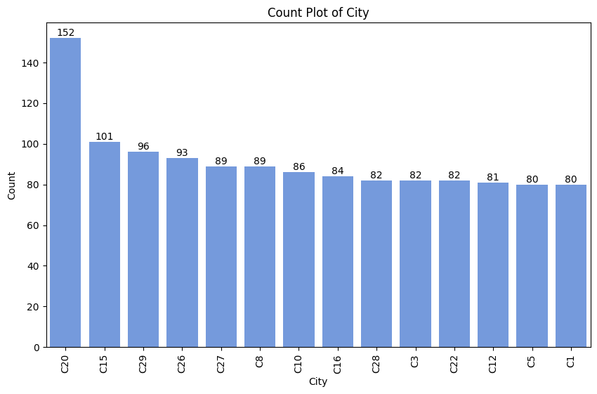

```
Total unique values:  29
```

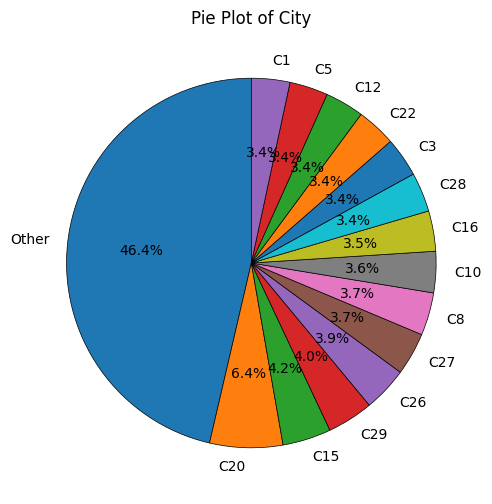

```
Total unique values:  3
```

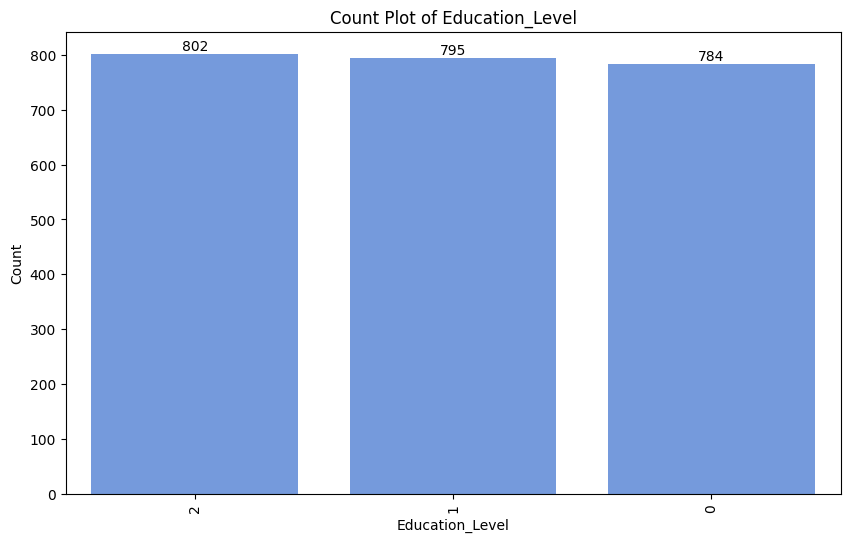

```
Total unique values:  3
```

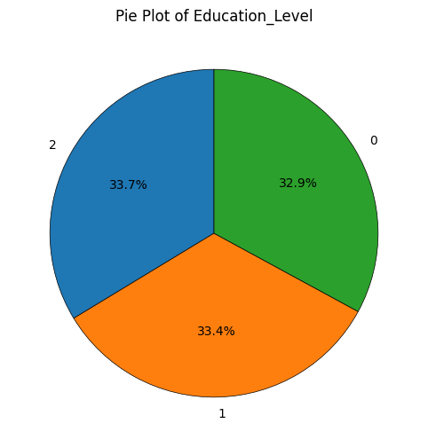

```
Total unique values:  5
```

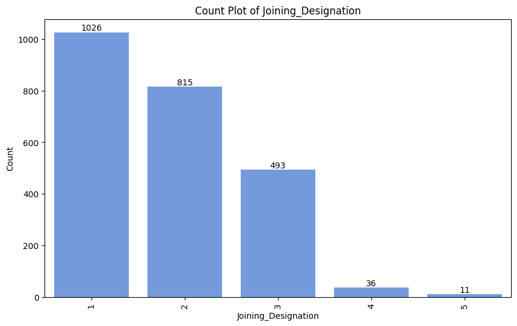

```
Total unique values:  5
```

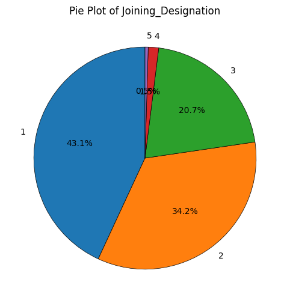

```
Total unique values:  5
```

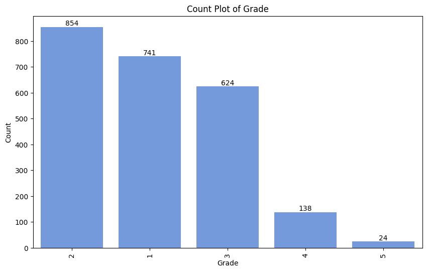

```
Total unique values:  5
```

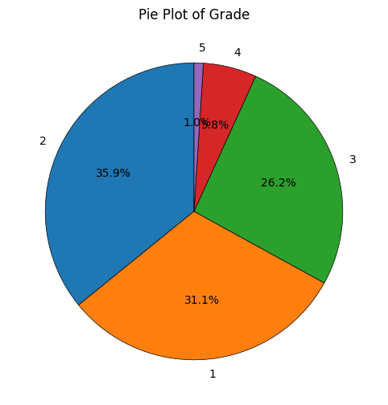

```
Total unique values:  2
```

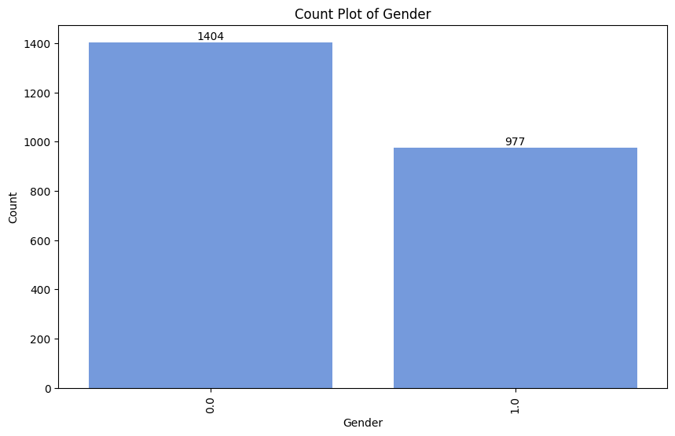

```
Total unique values:  2
```

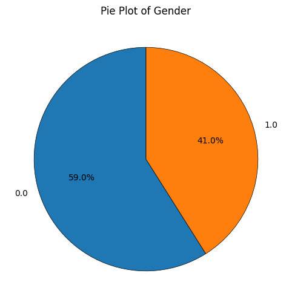

```
Total unique values:  2
```

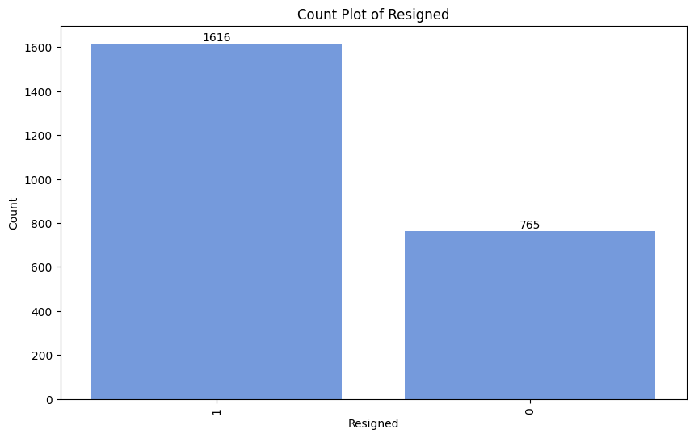

```
Total unique values:  2
```

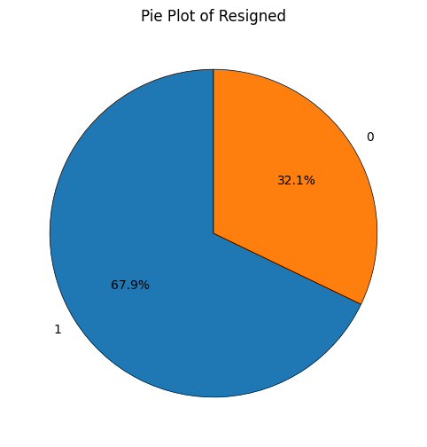

[12 more figures not shown]

```python
quick_eda_object = quick_eda_obj(grouped_data)
quick_eda_object.univariate_analysis(cat_col_list= categorical_features, num_col_list = num_features, top_n = 14)
```

```python
grouped_data.describe()
```

|  | Driver_ID | Education_Level | Income | Dateofjoining | Joining_Designation | Grade | Total_Business_Value | Gender | Age_at_joining | Resigned |
| --- | --- | --- | --- | --- | --- | --- | --- | --- | --- | --- |
| count | 2381.000000 | 2381.00000 | 2381.000000 | 2381 | 2381.000000 | 2381.000000 | 2.381000e+03 | 2381.000000 | 2381.000000 | 2381.000000 |
| mean | 1397.559009 | 1.00756 | 59336.159597 | 2019-02-08 07:14:50.550189056 | 1.820244 | 2.097018 | 4.586742e+06 | 0.410332 | 33.090718 | 0.678706 |
| min | 1.000000 | 0.00000 | 10747.000000 | 2013-04-01 00:00:00 | 1.000000 | 1.000000 | -1.385530e+06 | 0.000000 | 21.000000 | 0.000000 |
| 25% | 695.000000 | 0.00000 | 39104.000000 | 2018-06-29 00:00:00 | 1.000000 | 1.000000 | 0.000000e+00 | 0.000000 | 29.000000 | 0.000000 |
| 50% | 1400.000000 | 1.00000 | 55315.000000 | 2019-07-21 00:00:00 | 2.000000 | 2.000000 | 8.176800e+05 | 0.000000 | 33.000000 | 1.000000 |
| 75% | 2100.000000 | 2.00000 | 75986.000000 | 2020-05-02 00:00:00 | 2.000000 | 3.000000 | 4.173650e+06 | 1.000000 | 37.000000 | 1.000000 |
| max | 2788.000000 | 2.00000 | 188418.000000 | 2020-12-28 00:00:00 | 5.000000 | 5.000000 | 9.533106e+07 | 1.000000 | 58.000000 | 1.000000 |
| std | 806.161628 | 0.81629 | 28383.012146 | NaN | 0.841433 | 0.941702 | 9.127115e+06 | 0.491997 | 5.840686 | 0.467071 |

#### Bivariate Analysis

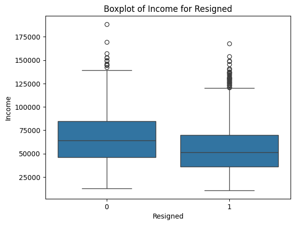

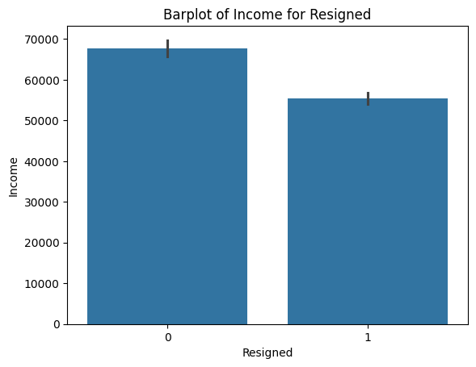

[figure not shown]

[figure not shown]

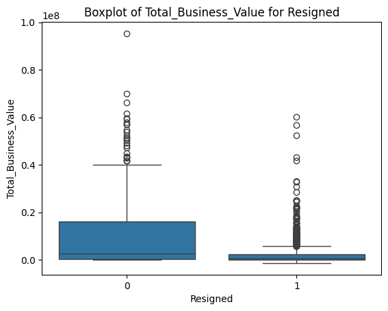

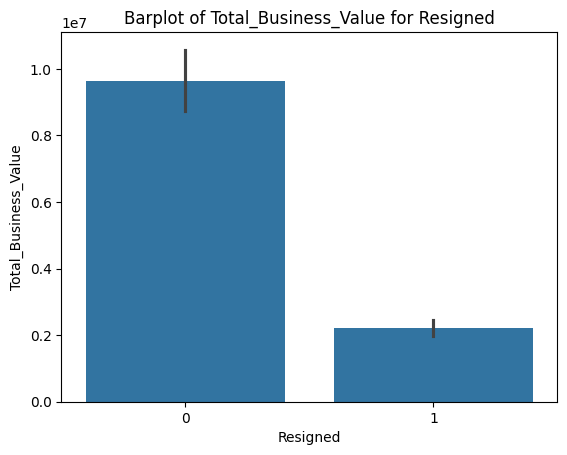

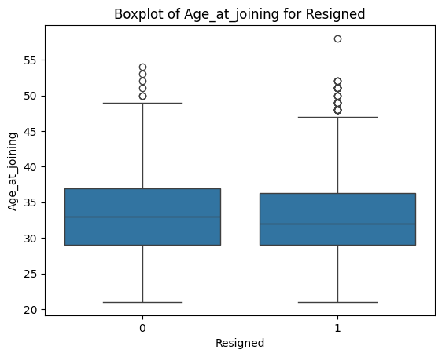

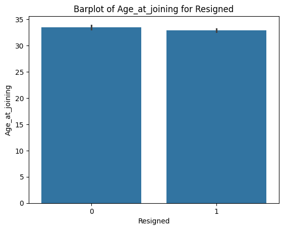

```
Total unique values for City is 29 and Resigned is 2
```

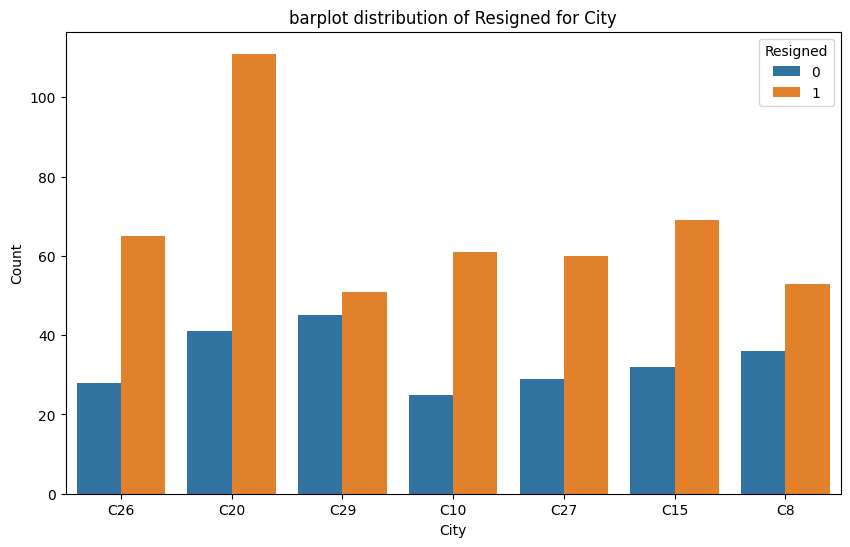

```
Total unique values for City is 29 and Resigned is 2
```

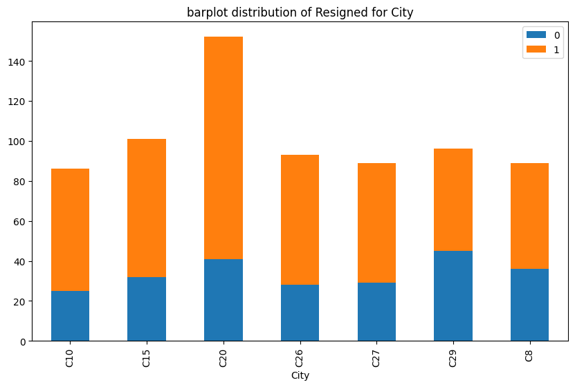

```
Total unique values for Education_Level is 3 and Resigned is 2
```

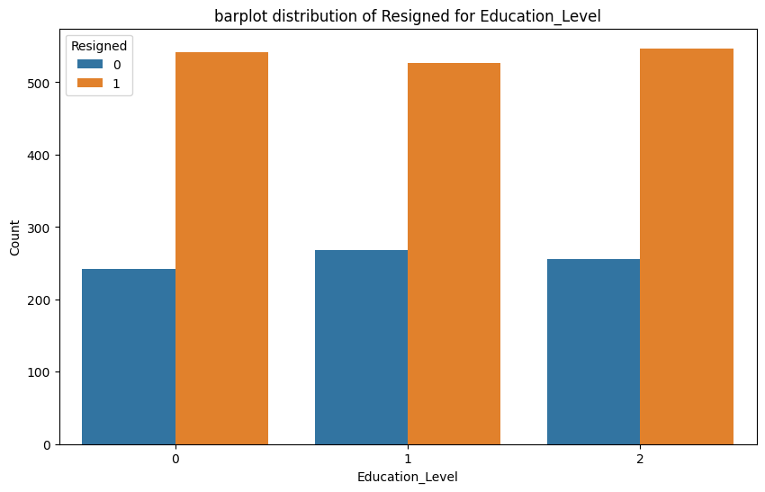

```
Total unique values for Education_Level is 3 and Resigned is 2
```

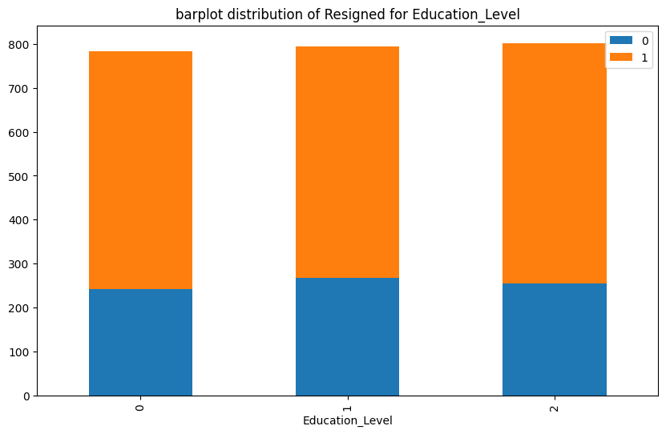

```
Total unique values for Joining_Designation is 5 and Resigned is 2
```

[8 more figures not shown]

```python
target_var = 'Resigned'
plotter_obj = Plotter(grouped_data)
# categorical VS target
for num_var in num_features:
  plotter_obj.bivariateboxplot(categorical_column = target_var, numerical_column = num_var, top_n =None)
  plotter_obj.bivariatebarplot(categorical_column = target_var, numerical_column = num_var, top_n =None)

for cat_var in categorical_features:
  plotter_obj.dodgedcountplot(x_column=cat_var, hue=target_var, top_n = 7)
  plotter_obj.stackedcountplot(x_column=cat_var, hue=target_var, top_n = 7)
```

Observations:

There are total 29 unique city codes of drivers. The maximum number of drivers(6.4%) have the city code of C20, followed by C15(4.2% drivers), C29(4% drivers). Ola’s drivers are fairly spread out rather than concentrated in one or two major cities.

33% of total drivers hold education level of 10+, 33.4% hold education level of 12+ and 33.7% are graduates.

The maximum number of drivers have designation of 1(43.1%drivers), followed by designation 2(34.2% drivers) and designation 3(20.7% drivers). Less than 1% of drivers have designation of 5.

The maximum number of drivers have Grade of 2 (36% drivers), followed by Grade 1(31.1% drivers) and Grade 3 (26.2% drivers). Less than 1% of drivers have Grade of 5.

59% of the drivers are Male and 41% are Females.

68% of total drivers have eventually left the company.

Half of the total drivers earn between ₹39K and ₹76K, with incomes ranging from a minimum of ₹10.7K to a maximum of ₹188.4K.

Half of the total drivers have a sum of Total Business Value between ₹0 and ₹4.17M, with values ranging from a minimum of -₹1.39M to a maximum of ₹95.33M.

Half of the total drivers were aged between 29-37 at the time of joining the company, with age ranging from a minimum of 21 to a maximum of 58.

Drivers who joined at lower designations and Grade (1 and 2) have a much higher resignation rate, whereas higher designations and Grade (3, 4, 5) show relatively fewer resignations.

# 4.Feature Engineering

```python
data.head()
```

|  | MMM-YY | Driver_ID | Age | City | Education_Level | Income | Dateofjoining | LastWorkingDate | Joining_Designation | Grade | Total_Business_Value | Quarterly_Rating | Age_at_joining | Gender | Resigned |
| --- | --- | --- | --- | --- | --- | --- | --- | --- | --- | --- | --- | --- | --- | --- | --- |
| 0 | 2019-01-01 | 1 | 28.0 | C23 | 2 | 57387 | 2018-12-24 | NaN | 1 | 1 | 2381060 | 2 | 28.0 | 0.0 | 0 |
| 1 | 2019-02-01 | 1 | 28.0 | C23 | 2 | 57387 | 2018-12-24 | NaN | 1 | 1 | -665480 | 2 | 28.0 | 0.0 | 0 |
| 2 | 2019-03-01 | 1 | 28.0 | C23 | 2 | 57387 | 2018-12-24 | 03/11/19 | 1 | 1 | 0 | 2 | 28.0 | 0.0 | 1 |
| 3 | 2020-11-01 | 2 | 31.0 | C7 | 2 | 67016 | 2020-11-06 | NaN | 2 | 2 | 0 | 1 | 31.0 | 0.0 | 0 |
| 4 | 2020-12-01 | 2 | 31.0 | C7 | 2 | 67016 | 2020-11-06 | NaN | 2 | 2 | 0 | 1 | 31.0 | 0.0 | 0 |

```python
data.sort_values(by = ['Driver_ID', 'MMM-YY'], ascending = True, inplace = True)
data.head()
```

|  | MMM-YY | Driver_ID | Age | City | Education_Level | Income | Dateofjoining | LastWorkingDate | Joining_Designation | Grade | Total_Business_Value | Quarterly_Rating | Age_at_joining | Gender | Resigned |
| --- | --- | --- | --- | --- | --- | --- | --- | --- | --- | --- | --- | --- | --- | --- | --- |
| 0 | 2019-01-01 | 1 | 28.0 | C23 | 2 | 57387 | 2018-12-24 | NaN | 1 | 1 | 2381060 | 2 | 28.0 | 0.0 | 0 |
| 1 | 2019-02-01 | 1 | 28.0 | C23 | 2 | 57387 | 2018-12-24 | NaN | 1 | 1 | -665480 | 2 | 28.0 | 0.0 | 0 |
| 2 | 2019-03-01 | 1 | 28.0 | C23 | 2 | 57387 | 2018-12-24 | 03/11/19 | 1 | 1 | 0 | 2 | 28.0 | 0.0 | 1 |
| 3 | 2020-11-01 | 2 | 31.0 | C7 | 2 | 67016 | 2020-11-06 | NaN | 2 | 2 | 0 | 1 | 31.0 | 0.0 | 0 |
| 4 | 2020-12-01 | 2 | 31.0 | C7 | 2 | 67016 | 2020-11-06 | NaN | 2 | 2 | 0 | 1 | 31.0 | 0.0 | 0 |

```python
data.head(20)
```

|  | MMM-YY | Driver_ID | Age | City | Education_Level | Income | Dateofjoining | LastWorkingDate | Joining_Designation | Grade | Total_Business_Value | Quarterly_Rating | Age_at_joining | Gender | Resigned |
| --- | --- | --- | --- | --- | --- | --- | --- | --- | --- | --- | --- | --- | --- | --- | --- |
| 0 | 2019-01-01 | 1 | 28.0 | C23 | 2 | 57387 | 2018-12-24 | NaN | 1 | 1 | 2381060 | 2 | 28.0 | 0.0 | 0 |
| 1 | 2019-02-01 | 1 | 28.0 | C23 | 2 | 57387 | 2018-12-24 | NaN | 1 | 1 | -665480 | 2 | 28.0 | 0.0 | 0 |
| 2 | 2019-03-01 | 1 | 28.0 | C23 | 2 | 57387 | 2018-12-24 | 03/11/19 | 1 | 1 | 0 | 2 | 28.0 | 0.0 | 1 |
| 3 | 2020-11-01 | 2 | 31.0 | C7 | 2 | 67016 | 2020-11-06 | NaN | 2 | 2 | 0 | 1 | 31.0 | 0.0 | 0 |
| 4 | 2020-12-01 | 2 | 31.0 | C7 | 2 | 67016 | 2020-11-06 | NaN | 2 | 2 | 0 | 1 | 31.0 | 0.0 | 0 |
| 5 | 2019-12-01 | 4 | 43.0 | C13 | 2 | 65603 | 2019-12-07 | NaN | 2 | 2 | 0 | 1 | 43.0 | 0.0 | 0 |
| 6 | 2020-01-01 | 4 | 43.0 | C13 | 2 | 65603 | 2019-12-07 | NaN | 2 | 2 | 0 | 1 | 43.0 | 0.0 | 0 |
| 7 | 2020-02-01 | 4 | 43.0 | C13 | 2 | 65603 | 2019-12-07 | NaN | 2 | 2 | 0 | 1 | 43.0 | 0.0 | 0 |
| 8 | 2020-03-01 | 4 | 43.0 | C13 | 2 | 65603 | 2019-12-07 | NaN | 2 | 2 | 350000 | 1 | 43.0 | 0.0 | 0 |
| 9 | 2020-04-01 | 4 | 43.0 | C13 | 2 | 65603 | 2019-12-07 | 27/04/20 | 2 | 2 | 0 | 1 | 43.0 | 0.0 | 1 |
| 10 | 2019-01-01 | 5 | 29.0 | C9 | 0 | 46368 | 2019-01-09 | NaN | 1 | 1 | 0 | 1 | 29.0 | 0.0 | 0 |
| 11 | 2019-02-01 | 5 | 29.0 | C9 | 0 | 46368 | 2019-01-09 | NaN | 1 | 1 | 120360 | 1 | 29.0 | 0.0 | 0 |
| 12 | 2019-03-01 | 5 | 29.0 | C9 | 0 | 46368 | 2019-01-09 | 03/07/19 | 1 | 1 | 0 | 1 | 29.0 | 0.0 | 1 |
| 13 | 2020-08-01 | 6 | 31.0 | C11 | 1 | 78728 | 2020-07-31 | NaN | 3 | 3 | 0 | 1 | 31.0 | 1.0 | 0 |
| 14 | 2020-09-01 | 6 | 31.0 | C11 | 1 | 78728 | 2020-07-31 | NaN | 3 | 3 | 0 | 1 | 31.0 | 1.0 | 0 |
| 15 | 2020-10-01 | 6 | 31.0 | C11 | 1 | 78728 | 2020-07-31 | NaN | 3 | 3 | 0 | 2 | 31.0 | 1.0 | 0 |
| 16 | 2020-11-01 | 6 | 31.0 | C11 | 1 | 78728 | 2020-07-31 | NaN | 3 | 3 | 1265000 | 2 | 31.0 | 1.0 | 0 |
| 17 | 2020-12-01 | 6 | 31.0 | C11 | 1 | 78728 | 2020-07-31 | NaN | 3 | 3 | 0 | 2 | 31.0 | 1.0 | 0 |
| 18 | 2020-09-01 | 8 | 34.0 | C2 | 0 | 70656 | 2020-09-19 | NaN | 3 | 3 | 0 | 1 | 34.0 | 0.0 | 0 |
| 19 | 2020-10-01 | 8 | 34.0 | C2 | 0 | 70656 | 2020-09-19 | NaN | 3 | 3 | 0 | 1 | 34.0 | 0.0 | 0 |

```python
data.tail()
```

|  | MMM-YY | Driver_ID | Age | City | Education_Level | Income | Dateofjoining | LastWorkingDate | Joining_Designation | Grade | Total_Business_Value | Quarterly_Rating | Age_at_joining | Gender | Resigned |
| --- | --- | --- | --- | --- | --- | --- | --- | --- | --- | --- | --- | --- | --- | --- | --- |
| 19099 | 2020-08-01 | 2788 | 30.0 | C27 | 2 | 70254 | 2020-06-08 | NaN | 2 | 2 | 740280 | 3 | 29.0 | 0.0 | 0 |
| 19100 | 2020-09-01 | 2788 | 30.0 | C27 | 2 | 70254 | 2020-06-08 | NaN | 2 | 2 | 448370 | 3 | 29.0 | 0.0 | 0 |
| 19101 | 2020-10-01 | 2788 | 30.0 | C27 | 2 | 70254 | 2020-06-08 | NaN | 2 | 2 | 0 | 2 | 29.0 | 0.0 | 0 |
| 19102 | 2020-11-01 | 2788 | 30.0 | C27 | 2 | 70254 | 2020-06-08 | NaN | 2 | 2 | 200420 | 2 | 29.0 | 0.0 | 0 |
| 19103 | 2020-12-01 | 2788 | 30.0 | C27 | 2 | 70254 | 2020-06-08 | NaN | 2 | 2 | 411480 | 2 | 29.0 | 0.0 | 0 |

For quarterly rating, we will create 2 columns. Last quarterly rating he has, and whether the quarterly rating has increased(1), decreased(-1) or remained same(0).

For income, we will create the last income he has, and whether the monthly income has increased for that driver - for those whose monthly income has increased we assign the value 1.

Since income increase and Grade increase hold same info, we just take the max grade and move on.

```python
quarterly_rating_shift = data.groupby('Driver_ID').agg(
    first_quarterly_rating=('Quarterly_Rating', 'first'),
    last_quarterly_rating=('Quarterly_Rating', 'last')
)

# Create a new column for the shift difference
quarterly_rating_shift['quarterly_rating_shift'] = (
    quarterly_rating_shift['last_quarterly_rating'] - quarterly_rating_shift['first_quarterly_rating']
)

# Keep only the necessary columns
quarterly_rating_shift = quarterly_rating_shift[['quarterly_rating_shift', 'last_quarterly_rating']]

quarterly_rating_shift.reset_index(inplace = True)
quarterly_rating_shift.head()
```

|  | Driver_ID | quarterly_rating_shift | last_quarterly_rating |
| --- | --- | --- | --- |
| 0 | 1 | 0 | 2 |
| 1 | 2 | 0 | 1 |
| 2 | 4 | 0 | 1 |
| 3 | 5 | 0 | 1 |
| 4 | 6 | 1 | 2 |

```python
quarterly_rating_shift[quarterly_rating_shift['quarterly_rating_shift'] > 0]
```

|  | Driver_ID | quarterly_rating_shift | last_quarterly_rating |
| --- | --- | --- | --- |
| 4 | 6 | 1 | 2 |
| 17 | 25 | 1 | 4 |
| 21 | 31 | 1 | 2 |
| 29 | 41 | 1 | 2 |
| 33 | 45 | 2 | 3 |
| ... | ... | ... | ... |
| 2352 | 2754 | 1 | 2 |
| 2358 | 2761 | 2 | 3 |
| 2374 | 2781 | 3 | 4 |
| 2376 | 2784 | 1 | 4 |
| 2380 | 2788 | 1 | 2 |

358 rows × 3 columns

```python
quarterly_rating_shift[quarterly_rating_shift['quarterly_rating_shift'] < 0]
```

|  | Driver_ID | quarterly_rating_shift | last_quarterly_rating |
| --- | --- | --- | --- |
| 7 | 12 | -3 | 1 |
| 11 | 17 | -1 | 1 |
| 14 | 21 | -3 | 1 |
| 15 | 22 | -1 | 1 |
| 18 | 26 | -2 | 2 |
| ... | ... | ... | ... |
| 2366 | 2771 | -1 | 1 |
| 2367 | 2772 | -1 | 1 |
| 2369 | 2774 | -3 | 1 |
| 2378 | 2786 | -1 | 1 |
| 2379 | 2787 | -1 | 1 |

458 rows × 3 columns

```python
data[data.Driver_ID == 12]
```

|  | MMM-YY | Driver_ID | Age | City | Education_Level | Income | Dateofjoining | LastWorkingDate | Joining_Designation | Grade | Total_Business_Value | Quarterly_Rating | Age_at_joining | Gender | Resigned |
| --- | --- | --- | --- | --- | --- | --- | --- | --- | --- | --- | --- | --- | --- | --- | --- |
| 22 | 2019-07-01 | 12 | 35.0 | C23 | 2 | 28116 | 2019-06-29 | NaN | 1 | 1 | 500000 | 4 | 35.0 | 0.0 | 0 |
| 23 | 2019-08-01 | 12 | 35.0 | C23 | 2 | 28116 | 2019-06-29 | NaN | 1 | 1 | 1707180 | 4 | 35.0 | 0.0 | 0 |
| 24 | 2019-09-01 | 12 | 35.0 | C23 | 2 | 28116 | 2019-06-29 | NaN | 1 | 1 | 400000 | 4 | 35.0 | 0.0 | 0 |
| 25 | 2019-10-01 | 12 | 35.0 | C23 | 2 | 28116 | 2019-06-29 | NaN | 1 | 1 | 0 | 1 | 35.0 | 0.0 | 0 |
| 26 | 2019-11-01 | 12 | 35.0 | C23 | 2 | 28116 | 2019-06-29 | NaN | 1 | 1 | 0 | 1 | 35.0 | 0.0 | 0 |
| 27 | 2019-12-01 | 12 | 35.0 | C23 | 2 | 28116 | 2019-06-29 | 21/12/19 | 1 | 1 | 0 | 1 | 35.0 | 0.0 | 1 |

```python
data[data.Driver_ID == 6]
```

|  | MMM-YY | Driver_ID | Age | City | Education_Level | Income | Dateofjoining | LastWorkingDate | Joining_Designation | Grade | Total_Business_Value | Quarterly_Rating | Age_at_joining | Gender | Resigned |
| --- | --- | --- | --- | --- | --- | --- | --- | --- | --- | --- | --- | --- | --- | --- | --- |
| 13 | 2020-08-01 | 6 | 31.0 | C11 | 1 | 78728 | 2020-07-31 | NaN | 3 | 3 | 0 | 1 | 31.0 | 1.0 | 0 |
| 14 | 2020-09-01 | 6 | 31.0 | C11 | 1 | 78728 | 2020-07-31 | NaN | 3 | 3 | 0 | 1 | 31.0 | 1.0 | 0 |
| 15 | 2020-10-01 | 6 | 31.0 | C11 | 1 | 78728 | 2020-07-31 | NaN | 3 | 3 | 0 | 2 | 31.0 | 1.0 | 0 |
| 16 | 2020-11-01 | 6 | 31.0 | C11 | 1 | 78728 | 2020-07-31 | NaN | 3 | 3 | 1265000 | 2 | 31.0 | 1.0 | 0 |
| 17 | 2020-12-01 | 6 | 31.0 | C11 | 1 | 78728 | 2020-07-31 | NaN | 3 | 3 | 0 | 2 | 31.0 | 1.0 | 0 |

```python
income_shift = data.groupby('Driver_ID').agg(
    first_income=('Income', 'first'),
    last_income=('Income', 'last')
)

# Calculate the shift in income
income_shift['income_shift'] = income_shift['last_income'] - income_shift['first_income']

# Keep only the necessary columns
income_shift = income_shift[['income_shift', 'last_income']]

income_shift.reset_index(inplace = True)
income_shift.head()
```

|  | Driver_ID | income_shift | last_income |
| --- | --- | --- | --- |
| 0 | 1 | 0 | 57387 |
| 1 | 2 | 0 | 67016 |
| 2 | 4 | 0 | 65603 |
| 3 | 5 | 0 | 46368 |
| 4 | 6 | 0 | 78728 |

```python
income_shift[income_shift['income_shift'] > 0]
```

|  | Driver_ID | income_shift | last_income |
| --- | --- | --- | --- |
| 18 | 26 | 11048 | 132577 |
| 40 | 54 | 9833 | 127826 |
| 46 | 60 | 7466 | 89592 |
| 80 | 98 | 5797 | 63774 |
| 230 | 275 | 8102 | 97226 |
| 256 | 307 | 7351 | 88207 |
| 267 | 320 | 6313 | 63126 |
| 312 | 368 | 5192 | 51911 |
| 368 | 434 | 8046 | 88515 |
| 460 | 537 | 7686 | 84554 |
| 488 | 568 | 5055 | 60655 |
| 500 | 580 | 5688 | 56877 |
| 550 | 638 | 11492 | 149403 |
| 615 | 716 | 5759 | 63352 |
| 672 | 789 | 6569 | 72265 |
| 756 | 888 | 5727 | 57266 |
| 877 | 1031 | 6221 | 68434 |
| 891 | 1050 | 3547 | 35462 |
| 986 | 1161 | 6124 | 67371 |
| 990 | 1165 | 8943 | 98374 |
| 1025 | 1206 | 6598 | 72584 |
| 1064 | 1249 | 3715 | 37143 |
| 1083 | 1274 | 12155 | 145861 |
| 1116 | 1316 | 6888 | 75773 |
| 1126 | 1327 | 3742 | 37413 |
| 1507 | 1770 | 7703 | 92440 |
| 1517 | 1783 | 4974 | 54718 |
| 1545 | 1817 | 5832 | 64154 |
| 1564 | 1840 | 3471 | 38183 |
| 1576 | 1852 | 6911 | 76029 |
| 1599 | 1877 | 9750 | 126742 |
| 1634 | 1918 | 6642 | 73070 |
| 1706 | 2008 | 3084 | 30840 |
| 1762 | 2070 | 6898 | 82773 |
| 1773 | 2087 | 9327 | 102597 |
| 1871 | 2198 | 7517 | 82691 |
| 1937 | 2272 | 8744 | 96185 |
| 2034 | 2390 | 5139 | 51383 |
| 2050 | 2407 | 7495 | 74945 |
| 2168 | 2543 | 5423 | 59662 |
| 2189 | 2567 | 11269 | 135231 |
| 2240 | 2625 | 4852 | 53377 |
| 2293 | 2690 | 7766 | 85428 |

```python
income_shift[income_shift['income_shift'] < 0]
```

|  | Driver_ID | income_shift | last_income |
| --- | --- | --- | --- |

```python
for col in data_ql.columns[1:]:
  print(data_ql[col].value_counts())
  print('*******************************')
```

```
City
1    2381
Name: count, dtype: int64
Education_Level
1    2381
Name: count, dtype: int64
Income
1    2337
2      44
Name: count, dtype: int64
Dateofjoining
1    2381
Name: count, dtype: int64
Joining_Designation
1    2381
Name: count, dtype: int64
Grade
1    2337
2      44
Name: count, dtype: int64
Quarterly_Rating
1    1277
2     657
3     356
4      91
Name: count, dtype: int64
```

```python
data = data.merge(quarterly_rating_shift, on = 'Driver_ID', how = 'left')
data = data.merge(income_shift, on = 'Driver_ID', how = 'left')
```

```python
data.head()
```

|  | MMM-YY | Driver_ID | Age | City | Education_Level | Income | Dateofjoining | LastWorkingDate | Joining_Designation | Grade | Total_Business_Value | Quarterly_Rating | Age_at_joining | Gender | Resigned | quarterly_rating_shift | last_quarterly_rating | income_shift | last_income |
| --- | --- | --- | --- | --- | --- | --- | --- | --- | --- | --- | --- | --- | --- | --- | --- | --- | --- | --- | --- |
| 0 | 2019-01-01 | 1 | 28.0 | C23 | 2 | 57387 | 2018-12-24 | NaN | 1 | 1 | 2381060 | 2 | 28.0 | 0.0 | 0 | 0 | 2 | 0 | 57387 |
| 1 | 2019-02-01 | 1 | 28.0 | C23 | 2 | 57387 | 2018-12-24 | NaN | 1 | 1 | -665480 | 2 | 28.0 | 0.0 | 0 | 0 | 2 | 0 | 57387 |
| 2 | 2019-03-01 | 1 | 28.0 | C23 | 2 | 57387 | 2018-12-24 | 03/11/19 | 1 | 1 | 0 | 2 | 28.0 | 0.0 | 1 | 0 | 2 | 0 | 57387 |
| 3 | 2020-11-01 | 2 | 31.0 | C7 | 2 | 67016 | 2020-11-06 | NaN | 2 | 2 | 0 | 1 | 31.0 | 0.0 | 0 | 0 | 1 | 0 | 67016 |
| 4 | 2020-12-01 | 2 | 31.0 | C7 | 2 | 67016 | 2020-11-06 | NaN | 2 | 2 | 0 | 1 | 31.0 | 0.0 | 0 | 0 | 1 | 0 | 67016 |

```python
grade_shift = data.groupby('Driver_ID').agg(
    last_grade=('Grade', 'last')
)

grade_shift.reset_index(inplace = True)
grade_shift.head()
```

|  | Driver_ID | last_grade |
| --- | --- | --- |
| 0 | 1 | 1 |
| 1 | 2 | 2 |
| 2 | 4 | 2 |
| 3 | 5 | 1 |
| 4 | 6 | 3 |

```python
data = data.merge(grade_shift, on = 'Driver_ID', how = 'left')
data.head()
```

|  | MMM-YY | Driver_ID | Age | City | Education_Level | Income | Dateofjoining | LastWorkingDate | Joining_Designation | Grade | Total_Business_Value | Quarterly_Rating | Age_at_joining | Gender | Resigned | quarterly_rating_shift | last_quarterly_rating | income_shift | last_income | last_grade |
| --- | --- | --- | --- | --- | --- | --- | --- | --- | --- | --- | --- | --- | --- | --- | --- | --- | --- | --- | --- | --- |
| 0 | 2019-01-01 | 1 | 28.0 | C23 | 2 | 57387 | 2018-12-24 | NaN | 1 | 1 | 2381060 | 2 | 28.0 | 0.0 | 0 | 0 | 2 | 0 | 57387 | 1 |
| 1 | 2019-02-01 | 1 | 28.0 | C23 | 2 | 57387 | 2018-12-24 | NaN | 1 | 1 | -665480 | 2 | 28.0 | 0.0 | 0 | 0 | 2 | 0 | 57387 | 1 |
| 2 | 2019-03-01 | 1 | 28.0 | C23 | 2 | 57387 | 2018-12-24 | 03/11/19 | 1 | 1 | 0 | 2 | 28.0 | 0.0 | 1 | 0 | 2 | 0 | 57387 | 1 |
| 3 | 2020-11-01 | 2 | 31.0 | C7 | 2 | 67016 | 2020-11-06 | NaN | 2 | 2 | 0 | 1 | 31.0 | 0.0 | 0 | 0 | 1 | 0 | 67016 | 2 |
| 4 | 2020-12-01 | 2 | 31.0 | C7 | 2 | 67016 | 2020-11-06 | NaN | 2 | 2 | 0 | 1 | 31.0 | 0.0 | 0 | 0 | 1 | 0 | 67016 | 2 |

```python
data.head(20)
```

|  | MMM-YY | Driver_ID | Age | City | Education_Level | Income | Dateofjoining | LastWorkingDate | Joining_Designation | Grade | Total_Business_Value | Quarterly_Rating | Age_at_joining | Gender | Resigned | quarterly_rating_shift | last_quarterly_rating | income_shift | last_income | last_grade |
| --- | --- | --- | --- | --- | --- | --- | --- | --- | --- | --- | --- | --- | --- | --- | --- | --- | --- | --- | --- | --- |
| 0 | 2019-01-01 | 1 | 28.0 | C23 | 2 | 57387 | 2018-12-24 | NaN | 1 | 1 | 2381060 | 2 | 28.0 | 0.0 | 0 | 0 | 2 | 0 | 57387 | 1 |
| 1 | 2019-02-01 | 1 | 28.0 | C23 | 2 | 57387 | 2018-12-24 | NaN | 1 | 1 | -665480 | 2 | 28.0 | 0.0 | 0 | 0 | 2 | 0 | 57387 | 1 |
| 2 | 2019-03-01 | 1 | 28.0 | C23 | 2 | 57387 | 2018-12-24 | 03/11/19 | 1 | 1 | 0 | 2 | 28.0 | 0.0 | 1 | 0 | 2 | 0 | 57387 | 1 |
| 3 | 2020-11-01 | 2 | 31.0 | C7 | 2 | 67016 | 2020-11-06 | NaN | 2 | 2 | 0 | 1 | 31.0 | 0.0 | 0 | 0 | 1 | 0 | 67016 | 2 |
| 4 | 2020-12-01 | 2 | 31.0 | C7 | 2 | 67016 | 2020-11-06 | NaN | 2 | 2 | 0 | 1 | 31.0 | 0.0 | 0 | 0 | 1 | 0 | 67016 | 2 |
| 5 | 2019-12-01 | 4 | 43.0 | C13 | 2 | 65603 | 2019-12-07 | NaN | 2 | 2 | 0 | 1 | 43.0 | 0.0 | 0 | 0 | 1 | 0 | 65603 | 2 |
| 6 | 2020-01-01 | 4 | 43.0 | C13 | 2 | 65603 | 2019-12-07 | NaN | 2 | 2 | 0 | 1 | 43.0 | 0.0 | 0 | 0 | 1 | 0 | 65603 | 2 |
| 7 | 2020-02-01 | 4 | 43.0 | C13 | 2 | 65603 | 2019-12-07 | NaN | 2 | 2 | 0 | 1 | 43.0 | 0.0 | 0 | 0 | 1 | 0 | 65603 | 2 |
| 8 | 2020-03-01 | 4 | 43.0 | C13 | 2 | 65603 | 2019-12-07 | NaN | 2 | 2 | 350000 | 1 | 43.0 | 0.0 | 0 | 0 | 1 | 0 | 65603 | 2 |
| 9 | 2020-04-01 | 4 | 43.0 | C13 | 2 | 65603 | 2019-12-07 | 27/04/20 | 2 | 2 | 0 | 1 | 43.0 | 0.0 | 1 | 0 | 1 | 0 | 65603 | 2 |
| 10 | 2019-01-01 | 5 | 29.0 | C9 | 0 | 46368 | 2019-01-09 | NaN | 1 | 1 | 0 | 1 | 29.0 | 0.0 | 0 | 0 | 1 | 0 | 46368 | 1 |
| 11 | 2019-02-01 | 5 | 29.0 | C9 | 0 | 46368 | 2019-01-09 | NaN | 1 | 1 | 120360 | 1 | 29.0 | 0.0 | 0 | 0 | 1 | 0 | 46368 | 1 |
| 12 | 2019-03-01 | 5 | 29.0 | C9 | 0 | 46368 | 2019-01-09 | 03/07/19 | 1 | 1 | 0 | 1 | 29.0 | 0.0 | 1 | 0 | 1 | 0 | 46368 | 1 |
| 13 | 2020-08-01 | 6 | 31.0 | C11 | 1 | 78728 | 2020-07-31 | NaN | 3 | 3 | 0 | 1 | 31.0 | 1.0 | 0 | 1 | 2 | 0 | 78728 | 3 |
| 14 | 2020-09-01 | 6 | 31.0 | C11 | 1 | 78728 | 2020-07-31 | NaN | 3 | 3 | 0 | 1 | 31.0 | 1.0 | 0 | 1 | 2 | 0 | 78728 | 3 |
| 15 | 2020-10-01 | 6 | 31.0 | C11 | 1 | 78728 | 2020-07-31 | NaN | 3 | 3 | 0 | 2 | 31.0 | 1.0 | 0 | 1 | 2 | 0 | 78728 | 3 |
| 16 | 2020-11-01 | 6 | 31.0 | C11 | 1 | 78728 | 2020-07-31 | NaN | 3 | 3 | 1265000 | 2 | 31.0 | 1.0 | 0 | 1 | 2 | 0 | 78728 | 3 |
| 17 | 2020-12-01 | 6 | 31.0 | C11 | 1 | 78728 | 2020-07-31 | NaN | 3 | 3 | 0 | 2 | 31.0 | 1.0 | 0 | 1 | 2 | 0 | 78728 | 3 |
| 18 | 2020-09-01 | 8 | 34.0 | C2 | 0 | 70656 | 2020-09-19 | NaN | 3 | 3 | 0 | 1 | 34.0 | 0.0 | 0 | 0 | 1 | 0 | 70656 | 3 |
| 19 | 2020-10-01 | 8 | 34.0 | C2 | 0 | 70656 | 2020-09-19 | NaN | 3 | 3 | 0 | 1 | 34.0 | 0.0 | 0 | 0 | 1 | 0 | 70656 | 3 |

```python
data.tail(20)
```

|  | MMM-YY | Driver_ID | Age | City | Education_Level | Income | Dateofjoining | LastWorkingDate | Joining_Designation | Grade | Total_Business_Value | Quarterly_Rating | Age_at_joining | Gender | Resigned | quarterly_rating_shift | last_quarterly_rating | income_shift | last_income | last_grade |
| --- | --- | --- | --- | --- | --- | --- | --- | --- | --- | --- | --- | --- | --- | --- | --- | --- | --- | --- | --- | --- |
| 19084 | 2019-03-01 | 2786 | 45.0 | C19 | 0 | 35370 | 2018-07-31 | NaN | 2 | 2 | 970380 | 2 | 44.0 | 0.0 | 0 | -1 | 1 | 0 | 35370 | 2 |
| 19085 | 2019-04-01 | 2786 | 45.0 | C19 | 0 | 35370 | 2018-07-31 | NaN | 2 | 2 | 432240 | 2 | 44.0 | 0.0 | 0 | -1 | 1 | 0 | 35370 | 2 |
| 19086 | 2019-05-01 | 2786 | 45.0 | C19 | 0 | 35370 | 2018-07-31 | NaN | 2 | 2 | 387660 | 2 | 44.0 | 0.0 | 0 | -1 | 1 | 0 | 35370 | 2 |
| 19087 | 2019-06-01 | 2786 | 45.0 | C19 | 0 | 35370 | 2018-07-31 | NaN | 2 | 2 | 0 | 2 | 44.0 | 0.0 | 0 | -1 | 1 | 0 | 35370 | 2 |
| 19088 | 2019-07-01 | 2786 | 45.0 | C19 | 0 | 35370 | 2018-07-31 | NaN | 2 | 2 | 318460 | 1 | 44.0 | 0.0 | 0 | -1 | 1 | 0 | 35370 | 2 |
| 19089 | 2019-08-01 | 2786 | 45.0 | C19 | 0 | 35370 | 2018-07-31 | NaN | 2 | 2 | 0 | 1 | 44.0 | 0.0 | 0 | -1 | 1 | 0 | 35370 | 2 |
| 19090 | 2019-09-01 | 2786 | 45.0 | C19 | 0 | 35370 | 2018-07-31 | 22/09/19 | 2 | 2 | 0 | 1 | 44.0 | 0.0 | 1 | -1 | 1 | 0 | 35370 | 2 |
| 19091 | 2019-01-01 | 2787 | 28.0 | C20 | 2 | 69498 | 2018-07-21 | NaN | 1 | 1 | 408090 | 2 | 28.0 | 1.0 | 0 | -1 | 1 | 0 | 69498 | 1 |
| 19092 | 2019-02-01 | 2787 | 28.0 | C20 | 2 | 69498 | 2018-07-21 | NaN | 1 | 1 | 250000 | 2 | 28.0 | 1.0 | 0 | -1 | 1 | 0 | 69498 | 1 |
| 19093 | 2019-03-01 | 2787 | 28.0 | C20 | 2 | 69498 | 2018-07-21 | NaN | 1 | 1 | 319740 | 2 | 28.0 | 1.0 | 0 | -1 | 1 | 0 | 69498 | 1 |
| 19094 | 2019-04-01 | 2787 | 28.0 | C20 | 2 | 69498 | 2018-07-21 | NaN | 1 | 1 | 0 | 1 | 28.0 | 1.0 | 0 | -1 | 1 | 0 | 69498 | 1 |
| 19095 | 2019-05-01 | 2787 | 28.0 | C20 | 2 | 69498 | 2018-07-21 | NaN | 1 | 1 | 0 | 1 | 28.0 | 1.0 | 0 | -1 | 1 | 0 | 69498 | 1 |
| 19096 | 2019-06-01 | 2787 | 28.0 | C20 | 2 | 69498 | 2018-07-21 | 20/06/19 | 1 | 1 | 0 | 1 | 28.0 | 1.0 | 1 | -1 | 1 | 0 | 69498 | 1 |
| 19097 | 2020-06-01 | 2788 | 29.0 | C27 | 2 | 70254 | 2020-06-08 | NaN | 2 | 2 | 0 | 1 | 29.0 | 0.0 | 0 | 1 | 2 | 0 | 70254 | 2 |
| 19098 | 2020-07-01 | 2788 | 30.0 | C27 | 2 | 70254 | 2020-06-08 | NaN | 2 | 2 | 497690 | 3 | 29.0 | 0.0 | 0 | 1 | 2 | 0 | 70254 | 2 |
| 19099 | 2020-08-01 | 2788 | 30.0 | C27 | 2 | 70254 | 2020-06-08 | NaN | 2 | 2 | 740280 | 3 | 29.0 | 0.0 | 0 | 1 | 2 | 0 | 70254 | 2 |
| 19100 | 2020-09-01 | 2788 | 30.0 | C27 | 2 | 70254 | 2020-06-08 | NaN | 2 | 2 | 448370 | 3 | 29.0 | 0.0 | 0 | 1 | 2 | 0 | 70254 | 2 |
| 19101 | 2020-10-01 | 2788 | 30.0 | C27 | 2 | 70254 | 2020-06-08 | NaN | 2 | 2 | 0 | 2 | 29.0 | 0.0 | 0 | 1 | 2 | 0 | 70254 | 2 |
| 19102 | 2020-11-01 | 2788 | 30.0 | C27 | 2 | 70254 | 2020-06-08 | NaN | 2 | 2 | 200420 | 2 | 29.0 | 0.0 | 0 | 1 | 2 | 0 | 70254 | 2 |
| 19103 | 2020-12-01 | 2788 | 30.0 | C27 | 2 | 70254 | 2020-06-08 | NaN | 2 | 2 | 411480 | 2 | 29.0 | 0.0 | 0 | 1 | 2 | 0 | 70254 | 2 |

```python
data.head()
```

|  | MMM-YY | Driver_ID | Age | City | Education_Level | Income | Dateofjoining | LastWorkingDate | Joining_Designation | Grade | Total_Business_Value | Quarterly_Rating | Age_at_joining | Gender | Resigned | quarterly_rating_shift | last_quarterly_rating | income_shift | last_income | last_grade |
| --- | --- | --- | --- | --- | --- | --- | --- | --- | --- | --- | --- | --- | --- | --- | --- | --- | --- | --- | --- | --- |
| 0 | 2019-01-01 | 1 | 28.0 | C23 | 2 | 57387 | 2018-12-24 | NaN | 1 | 1 | 2381060 | 2 | 28.0 | 0.0 | 0 | 0 | 2 | 0 | 57387 | 1 |
| 1 | 2019-02-01 | 1 | 28.0 | C23 | 2 | 57387 | 2018-12-24 | NaN | 1 | 1 | -665480 | 2 | 28.0 | 0.0 | 0 | 0 | 2 | 0 | 57387 | 1 |
| 2 | 2019-03-01 | 1 | 28.0 | C23 | 2 | 57387 | 2018-12-24 | 03/11/19 | 1 | 1 | 0 | 2 | 28.0 | 0.0 | 1 | 0 | 2 | 0 | 57387 | 1 |
| 3 | 2020-11-01 | 2 | 31.0 | C7 | 2 | 67016 | 2020-11-06 | NaN | 2 | 2 | 0 | 1 | 31.0 | 0.0 | 0 | 0 | 1 | 0 | 67016 | 2 |
| 4 | 2020-12-01 | 2 | 31.0 | C7 | 2 | 67016 | 2020-11-06 | NaN | 2 | 2 | 0 | 1 | 31.0 | 0.0 | 0 | 0 | 1 | 0 | 67016 | 2 |

For quarterly rating, we will create 2 columns. Last quarterly rating he has, and whether the quarterly rating has increased(1), decreased(-1) or remained same(0).

For income, we will create the last income he has, and whether the monthly income has increased for that driver - for those whose monthly income has increased we assign the value 1.

Since income increase and Grade increase hold same info, we just take the max grade and move on.

```python
data.head(2)
```

|  | MMM-YY | Driver_ID | Age | City | Education_Level | Income | Dateofjoining | LastWorkingDate | Joining_Designation | Grade | Total_Business_Value | Quarterly_Rating | Age_at_joining | Gender | Resigned | quarterly_rating_shift | last_quarterly_rating | income_shift | last_income | last_grade |
| --- | --- | --- | --- | --- | --- | --- | --- | --- | --- | --- | --- | --- | --- | --- | --- | --- | --- | --- | --- | --- |
| 0 | 2019-01-01 | 1 | 28.0 | C23 | 2 | 57387 | 2018-12-24 | NaN | 1 | 1 | 2381060 | 2 | 28.0 | 0.0 | 0 | 0 | 2 | 0 | 57387 | 1 |
| 1 | 2019-02-01 | 1 | 28.0 | C23 | 2 | 57387 | 2018-12-24 | NaN | 1 | 1 | -665480 | 2 | 28.0 | 0.0 | 0 | 0 | 2 | 0 | 57387 | 1 |

```python
data['quarterly_rating_shift'] = data['quarterly_rating_shift'].apply(lambda x: 1 if x > 0 else (-1 if x < 0 else 0))
data['income_shift'] = data['income_shift'].apply(lambda x: 1 if x > 0 else 0)
```

```python
data.head()
```

|  | MMM-YY | Driver_ID | Age | City | Education_Level | Income | Dateofjoining | LastWorkingDate | Joining_Designation | Grade | Total_Business_Value | Quarterly_Rating | Age_at_joining | Gender | Resigned | quarterly_rating_shift | last_quarterly_rating | income_shift | last_income | last_grade |
| --- | --- | --- | --- | --- | --- | --- | --- | --- | --- | --- | --- | --- | --- | --- | --- | --- | --- | --- | --- | --- |
| 0 | 2019-01-01 | 1 | 28.0 | C23 | 2 | 57387 | 2018-12-24 | NaN | 1 | 1 | 2381060 | 2 | 28.0 | 0.0 | 0 | 0 | 2 | 0 | 57387 | 1 |
| 1 | 2019-02-01 | 1 | 28.0 | C23 | 2 | 57387 | 2018-12-24 | NaN | 1 | 1 | -665480 | 2 | 28.0 | 0.0 | 0 | 0 | 2 | 0 | 57387 | 1 |
| 2 | 2019-03-01 | 1 | 28.0 | C23 | 2 | 57387 | 2018-12-24 | 03/11/19 | 1 | 1 | 0 | 2 | 28.0 | 0.0 | 1 | 0 | 2 | 0 | 57387 | 1 |
| 3 | 2020-11-01 | 2 | 31.0 | C7 | 2 | 67016 | 2020-11-06 | NaN | 2 | 2 | 0 | 1 | 31.0 | 0.0 | 0 | 0 | 1 | 0 | 67016 | 2 |
| 4 | 2020-12-01 | 2 | 31.0 | C7 | 2 | 67016 | 2020-11-06 | NaN | 2 | 2 | 0 | 1 | 31.0 | 0.0 | 0 | 0 | 1 | 0 | 67016 | 2 |

```python
final_driver_data = data.groupby('Driver_ID').agg({'City':'max',
                                                   'Education_Level' : 'max',
                                                   'Age_at_joining':'max',
                                                   'last_income':'max',
                                                   'income_shift': 'max',
                                                   'Resigned':'max',
                                                   'Joining_Designation':'max',
                                                   'last_grade':'max',
                                                   'Total_Business_Value':'sum',
                                                   'last_quarterly_rating':'max',
                                                   'quarterly_rating_shift':'max',
                                                   'Gender':'max'
                                                   }).reset_index()

final_driver_data.head()
```

|  | Driver_ID | City | Education_Level | Age_at_joining | last_income | income_shift | Resigned | Joining_Designation | last_grade | Total_Business_Value | last_quarterly_rating | quarterly_rating_shift | Gender |
| --- | --- | --- | --- | --- | --- | --- | --- | --- | --- | --- | --- | --- | --- |
| 0 | 1 | C23 | 2 | 28.0 | 57387 | 0 | 1 | 1 | 1 | 1715580 | 2 | 0 | 0.0 |
| 1 | 2 | C7 | 2 | 31.0 | 67016 | 0 | 0 | 2 | 2 | 0 | 1 | 0 | 0.0 |
| 2 | 4 | C13 | 2 | 43.0 | 65603 | 0 | 1 | 2 | 2 | 350000 | 1 | 0 | 0.0 |
| 3 | 5 | C9 | 0 | 29.0 | 46368 | 0 | 1 | 1 | 1 | 120360 | 1 | 0 | 0.0 |
| 4 | 6 | C11 | 1 | 31.0 | 78728 | 0 | 0 | 3 | 3 | 1265000 | 2 | 1 | 1.0 |

```python
final_driver_data.shape
```

```
(2381, 13)
```

```python
final_driver_data[final_driver_data.Resigned == 1].shape[0]/final_driver_data.shape[0]
```

```
0.6787064258714826
```

# 5.Data encoding, upsampling

```python
final_driver_data.head()
```

|  | Driver_ID | City | Education_Level | Age_at_joining | last_income | income_shift | Resigned | Joining_Designation | last_grade | Total_Business_Value | last_quarterly_rating | quarterly_rating_shift | Gender |
| --- | --- | --- | --- | --- | --- | --- | --- | --- | --- | --- | --- | --- | --- |
| 0 | 1 | C23 | 2 | 28.0 | 57387 | 0 | 1 | 1 | 1 | 1715580 | 2 | 0 | 0.0 |
| 1 | 2 | C7 | 2 | 31.0 | 67016 | 0 | 0 | 2 | 2 | 0 | 1 | 0 | 0.0 |
| 2 | 4 | C13 | 2 | 43.0 | 65603 | 0 | 1 | 2 | 2 | 350000 | 1 | 0 | 0.0 |
| 3 | 5 | C9 | 0 | 29.0 | 46368 | 0 | 1 | 1 | 1 | 120360 | 1 | 0 | 0.0 |
| 4 | 6 | C11 | 1 | 31.0 | 78728 | 0 | 0 | 3 | 3 | 1265000 | 2 | 1 | 1.0 |

```python
final_driver_data.Gender.value_counts()
```

| Gender | count |
| --- | --- |
| 0.0 | 1404 |
| 1.0 | 977 |

**dtype:** int64

```python
final_driver_data.info()
```

```
<class 'pandas.core.frame.DataFrame'>
RangeIndex: 2381 entries, 0 to 2380
Data columns (total 13 columns):
 #   Column                  Non-Null Count  Dtype
---  ------                  --------------  -----
 0   Driver_ID               2381 non-null   int64
 1   City                    2381 non-null   object
 2   Education_Level         2381 non-null   int64
 3   Age_at_joining          2381 non-null   float64
 4   last_income             2381 non-null   int64
 5   income_shift            2381 non-null   int64
 6   Resigned                2381 non-null   int64
 7   Joining_Designation     2381 non-null   int64
 8   last_grade              2381 non-null   int64
 9   Total_Business_Value    2381 non-null   int64
 10  last_quarterly_rating   2381 non-null   int64
 11  quarterly_rating_shift  2381 non-null   int64
 12  Gender                  2381 non-null   float64
dtypes: float64(2), int64(10), object(1)
memory usage: 241.9+ KB
```

```python
# columns_to_convert = ['Education_Level', 'income_shift', 'Joining_Designation', 'last_grade', 'last_quarterly_rating', 'quarterly_rating_shift', 'Gender']  # Replace with actual column names
# final_driver_data[columns_to_convert] = final_driver_data[columns_to_convert].astype('object')
final_driver_data[['Age_at_joining', 'Gender']] = final_driver_data[['Age_at_joining', 'Gender']].astype('int')

final_driver_data.info()
```

```
<class 'pandas.core.frame.DataFrame'>
RangeIndex: 2381 entries, 0 to 2380
Data columns (total 13 columns):
 #   Column                  Non-Null Count  Dtype
---  ------                  --------------  -----
 0   Driver_ID               2381 non-null   int64
 1   City                    2381 non-null   object
 2   Education_Level         2381 non-null   int64
 3   Age_at_joining          2381 non-null   int64
 4   last_income             2381 non-null   int64
 5   income_shift            2381 non-null   int64
 6   Resigned                2381 non-null   int64
 7   Joining_Designation     2381 non-null   int64
 8   last_grade              2381 non-null   int64
 9   Total_Business_Value    2381 non-null   int64
 10  last_quarterly_rating   2381 non-null   int64
 11  quarterly_rating_shift  2381 non-null   int64
 12  Gender                  2381 non-null   int64
dtypes: int64(12), object(1)
memory usage: 241.9+ KB
```

## Encoding

```python
final_driver_data.head()
```

|  | Driver_ID | City | Education_Level | Age_at_joining | last_income | income_shift | Resigned | Joining_Designation | last_grade | Total_Business_Value | last_quarterly_rating | quarterly_rating_shift | Gender |
| --- | --- | --- | --- | --- | --- | --- | --- | --- | --- | --- | --- | --- | --- |
| 0 | 1 | C23 | 2 | 28 | 57387 | 0 | 1 | 1 | 1 | 1715580 | 2 | 0 | 0 |
| 1 | 2 | C7 | 2 | 31 | 67016 | 0 | 0 | 2 | 2 | 0 | 1 | 0 | 0 |
| 2 | 4 | C13 | 2 | 43 | 65603 | 0 | 1 | 2 | 2 | 350000 | 1 | 0 | 0 |
| 3 | 5 | C9 | 0 | 29 | 46368 | 0 | 1 | 1 | 1 | 120360 | 1 | 0 | 0 |
| 4 | 6 | C11 | 1 | 31 | 78728 | 0 | 0 | 3 | 3 | 1265000 | 2 | 1 | 1 |

```python
one_hot_endoded_data = pd.get_dummies(final_driver_data, columns = ['City'], dtype = int)
one_hot_endoded_data.head()
```

|  | Driver_ID | Education_Level | Age_at_joining | last_income | income_shift | Resigned | Joining_Designation | last_grade | Total_Business_Value | last_quarterly_rating | quarterly_rating_shift | Gender | City_C1 | City_C10 | City_C11 | City_C12 | City_C13 | City_C14 | City_C15 | City_C16 | City_C17 | City_C18 | City_C19 | City_C2 | City_C20 | City_C21 | City_C22 | City_C23 | City_C24 | … |
| --- | --- | --- | --- | --- | --- | --- | --- | --- | --- | --- | --- | --- | --- | --- | --- | --- | --- | --- | --- | --- | --- | --- | --- | --- | --- | --- | --- | --- | --- | --- |
| 0 | 1 | 2 | 28 | 57387 | 0 | 1 | 1 | 1 | 1715580 | 2 | 0 | 0 | 0 | 0 | 0 | 0 | 0 | 0 | 0 | 0 | 0 | 0 | 0 | 0 | 0 | 0 | 0 | 1 | 0 | … |
| 1 | 2 | 2 | 31 | 67016 | 0 | 0 | 2 | 2 | 0 | 1 | 0 | 0 | 0 | 0 | 0 | 0 | 0 | 0 | 0 | 0 | 0 | 0 | 0 | 0 | 0 | 0 | 0 | 0 | 0 | … |
| 2 | 4 | 2 | 43 | 65603 | 0 | 1 | 2 | 2 | 350000 | 1 | 0 | 0 | 0 | 0 | 0 | 0 | 1 | 0 | 0 | 0 | 0 | 0 | 0 | 0 | 0 | 0 | 0 | 0 | 0 | … |
| 3 | 5 | 0 | 29 | 46368 | 0 | 1 | 1 | 1 | 120360 | 1 | 0 | 0 | 0 | 0 | 0 | 0 | 0 | 0 | 0 | 0 | 0 | 0 | 0 | 0 | 0 | 0 | 0 | 0 | 0 | … |
| 4 | 6 | 1 | 31 | 78728 | 0 | 0 | 3 | 3 | 1265000 | 2 | 1 | 1 | 0 | 0 | 1 | 0 | 0 | 0 | 0 | 0 | 0 | 0 | 0 | 0 | 0 | 0 | 0 | 0 | 0 | … |

```python
label_encoded_data = final_driver_data.copy()
label_encoded_data['City'] = label_encoded_data['City'].astype('category')
label_encoded_data['City'] = label_encoded_data['City'].cat.codes
label_encoded_data.head()
```

|  | Driver_ID | City | Education_Level | Age_at_joining | last_income | income_shift | Resigned | Joining_Designation | last_grade | Total_Business_Value | last_quarterly_rating | quarterly_rating_shift | Gender |
| --- | --- | --- | --- | --- | --- | --- | --- | --- | --- | --- | --- | --- | --- |
| 0 | 1 | 15 | 2 | 28 | 57387 | 0 | 1 | 1 | 1 | 1715580 | 2 | 0 | 0 |
| 1 | 2 | 26 | 2 | 31 | 67016 | 0 | 0 | 2 | 2 | 0 | 1 | 0 | 0 |
| 2 | 4 | 4 | 2 | 43 | 65603 | 0 | 1 | 2 | 2 | 350000 | 1 | 0 | 0 |
| 3 | 5 | 28 | 0 | 29 | 46368 | 0 | 1 | 1 | 1 | 120360 | 1 | 0 | 0 |
| 4 | 6 | 2 | 1 | 31 | 78728 | 0 | 0 | 3 | 3 | 1265000 | 2 | 1 | 1 |

## Train-test split

```python
X_onehot = one_hot_endoded_data.drop(columns = ['Driver_ID', 'Resigned'])
Y_onehot = one_hot_endoded_data['Resigned']

X_label_encoded = label_encoded_data.drop(columns = ['Driver_ID', 'Resigned'])
Y_label_encoded = label_encoded_data['Resigned']

X_train_onehot, X_test_onehot, Y_train_onehot, Y_test_onehot = train_test_split(X_onehot, Y_onehot, test_size=0.2, random_state=42)
X_train_label_encoded, X_test_label_encoded, Y_train_label_encoded, Y_test_label_encoded = train_test_split(X_label_encoded, Y_label_encoded, test_size=0.2, random_state=42)

# Check the shapes to confirm correct splits
print(f"X_train: {X_train_onehot.shape}, X_test: {X_test_onehot.shape}")
print(f"Y_train: {Y_train_onehot.shape}, Y_test: {Y_test_onehot.shape}")
print(f"X_train: {X_train_label_encoded.shape}, X_test: {X_test_label_encoded.shape}")
print(f"Y_train: {Y_train_label_encoded.shape}, Y_test: {Y_test_label_encoded.shape}")
```

```
X_train: (1904, 39), X_test: (477, 39)
Y_train: (1904,), Y_test: (477,)
X_train: (1904, 11), X_test: (477, 11)
Y_train: (1904,), Y_test: (477,)
```

## Upsampling

```python
smt = SMOTE()
# Perform SMOTE on the training data
print('Before SMOTE')
print(Y_train_onehot.value_counts())
X_train_onehot_sm, y_train_onehot_sm = smt.fit_resample(X_train_onehot, Y_train_onehot)
X_train_label_encoded_sm, y_train_label_encoded_sm = smt.fit_resample(X_train_label_encoded, Y_train_label_encoded)
print('After Oversampling')
print(y_train_onehot_sm.value_counts())
print(y_train_label_encoded_sm.value_counts())
```

```
Before SMOTE
Resigned
1    1289
0     615
Name: count, dtype: int64
After Oversampling
Resigned
0    1289
1    1289
Name: count, dtype: int64
Resigned
0    1289
1    1289
Name: count, dtype: int64
```

```python
X_train_onehot_sm.head()
```

|  | Education_Level | Age_at_joining | last_income | income_shift | Joining_Designation | last_grade | Total_Business_Value | last_quarterly_rating | quarterly_rating_shift | Gender | City_C1 | City_C10 | City_C11 | City_C12 | City_C13 | City_C14 | City_C15 | City_C16 | City_C17 | City_C18 | City_C19 | City_C2 | City_C20 | City_C21 | City_C22 | City_C23 | City_C24 | City_C25 | City_C26 | … |
| --- | --- | --- | --- | --- | --- | --- | --- | --- | --- | --- | --- | --- | --- | --- | --- | --- | --- | --- | --- | --- | --- | --- | --- | --- | --- | --- | --- | --- | --- | --- |
| 0 | 0 | 28 | 87872 | 0 | 3 | 3 | 0 | 1 | 0 | 0 | 0 | 1 | 0 | 0 | 0 | 0 | 0 | 0 | 0 | 0 | 0 | 0 | 0 | 0 | 0 | 0 | 0 | 0 | 0 | … |
| 1 | 0 | 34 | 38619 | 0 | 2 | 2 | 466160 | 1 | 0 | 0 | 0 | 0 | 0 | 0 | 0 | 0 | 0 | 0 | 0 | 0 | 0 | 0 | 1 | 0 | 0 | 0 | 0 | 0 | 0 | … |
| 2 | 0 | 27 | 53105 | 0 | 1 | 2 | 0 | 1 | 0 | 0 | 0 | 0 | 0 | 0 | 0 | 0 | 0 | 0 | 0 | 0 | 0 | 0 | 0 | 0 | 0 | 0 | 0 | 0 | 0 | … |
| 3 | 2 | 29 | 34234 | 0 | 1 | 1 | 3489080 | 2 | 1 | 1 | 0 | 0 | 0 | 0 | 0 | 0 | 0 | 0 | 0 | 0 | 0 | 0 | 0 | 0 | 1 | 0 | 0 | 0 | 0 | … |
| 4 | 0 | 45 | 90484 | 0 | 1 | 3 | 22388420 | 3 | -1 | 0 | 0 | 0 | 0 | 0 | 0 | 0 | 0 | 0 | 0 | 0 | 0 | 0 | 0 | 0 | 1 | 0 | 0 | 0 | 0 | … |

# 6.Model experimentation

## Decision Tree

```python
# Identify numerical columns
numerical_cols = ['last_income', 'Age_at_joining', 'Total_Business_Value']  # Add other numerical columns if needed

# Standardize only numerical columns
preprocessor = ColumnTransformer(
    transformers=[
        ('num', StandardScaler(), numerical_cols)  # Apply StandardScaler only to numeric columns
    ],
    remainder='passthrough'  # Keep other columns unchanged
)

# Define pipeline
pipeline = Pipeline([
    ('scaler', preprocessor),  # Standardization
    ('classifier', DecisionTreeClassifier(random_state=42))
])

# Define hyperparameter grid for Randomized Search
param_dist = {
    'classifier__max_depth': [3, 5, 10, None],
    'classifier__min_samples_split': [2, 5, 10, 20],
    'classifier__min_samples_leaf': [1, 2, 4, 8],
    'classifier__criterion': ['gini', 'entropy']
}

# Perform Stratified K-Fold Cross-Validation with Randomized Search
cv = StratifiedKFold(n_splits=5, shuffle=True, random_state=42)
```

```python
random_search_label_encoded_sm = RandomizedSearchCV(pipeline, param_distributions=param_dist,
                                   cv=cv, scoring='recall',
                                   n_iter=20, random_state=42, n_jobs=-1)

# Fit the model
random_search_label_encoded_sm.fit(X_train_label_encoded_sm, y_train_label_encoded_sm)

# Print best parameters and score
print("Best Parameters:", random_search_label_encoded_sm.best_params_)
print("Best Score:", random_search_label_encoded_sm.best_score_)
```

```
Best Parameters: {'classifier__min_samples_split': 2, 'classifier__min_samples_leaf': 2, 'classifier__max_depth': 3, 'classifier__criterion': 'gini'}
Best Score: 0.8882604892468253
```

```python
random_search_onehot_sm = RandomizedSearchCV(pipeline, param_distributions=param_dist,
                                   cv=cv, scoring='recall',
                                   n_iter=20, random_state=42, n_jobs=-1)

# Fit the model
random_search_onehot_sm.fit(X_train_onehot_sm, y_train_onehot_sm)

# Print best parameters and score
print("Best Parameters:", random_search_onehot_sm.best_params_)
print("Best Score:", random_search_onehot_sm.best_score_)
```

```
Best Parameters: {'classifier__min_samples_split': 10, 'classifier__min_samples_leaf': 8, 'classifier__max_depth': 5, 'classifier__criterion': 'entropy'}
Best Score: 0.8898138931620064
```

```python
random_search_onehot = RandomizedSearchCV(pipeline, param_distributions=param_dist,
                                   cv=cv, scoring='recall',
                                   n_iter=20, random_state=42, n_jobs=-1)

# Fit the model
random_search_onehot.fit(X_train_onehot, Y_train_onehot)

# Print best parameters and score
print("Best Parameters:", random_search_onehot.best_params_)
print("Best Score:", random_search_onehot.best_score_)
```

```
Best Parameters: {'classifier__min_samples_split': 2, 'classifier__min_samples_leaf': 1, 'classifier__max_depth': 5, 'classifier__criterion': 'entropy'}
Best Score: 0.9239706813863
```

```python
random_search_label_encoded = RandomizedSearchCV(pipeline, param_distributions=param_dist,
                                   cv=cv, scoring='recall',
                                   n_iter=20, random_state=42, n_jobs=-1)

# Fit the model
random_search_label_encoded.fit(X_train_label_encoded, Y_train_label_encoded)

# Print best parameters and score
print("Best Parameters:", random_search_label_encoded.best_params_)
print("Best Score:", random_search_label_encoded.best_score_)
```

```
Best Parameters: {'classifier__min_samples_split': 10, 'classifier__min_samples_leaf': 4, 'classifier__max_depth': 5, 'classifier__criterion': 'gini'}
Best Score: 0.9216481163092329
```

```python
best_model_label_encoded_sm = random_search_label_encoded_sm.best_estimator_
best_model_onehot_sm = random_search_onehot_sm.best_estimator_
best_model_onehot = random_search_onehot.best_estimator_
best_model_label_encoded = random_search_label_encoded.best_estimator_
```

```python
Y_test_onehot_predict = best_model_onehot.predict(X_test_onehot)
Y_test_label_encoded_predict = best_model_label_encoded.predict(X_test_label_encoded)
Y_test_onehot_predict_sm = best_model_onehot_sm.predict(X_test_onehot)
Y_test_label_encoded_predict_sm = best_model_label_encoded_sm.predict(X_test_label_encoded)
```

```
<sklearn.metrics._plot.confusion_matrix.ConfusionMatrixDisplay at 0x7fc5f6f06ad0>
```

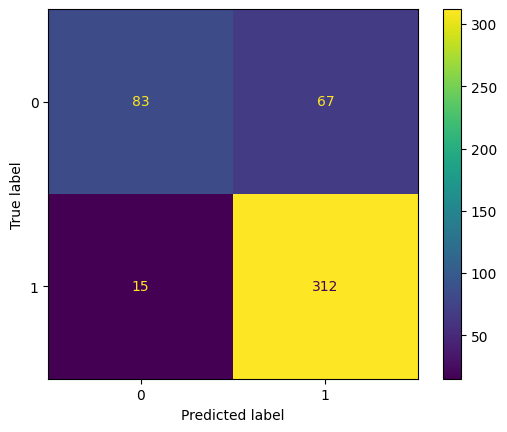

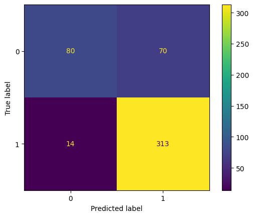

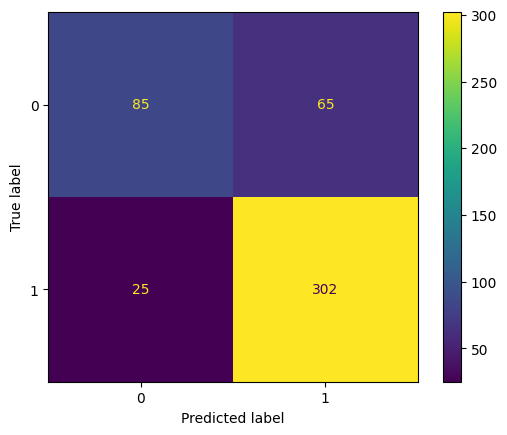

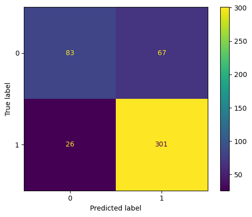

```python
ConfusionMatrixDisplay(confusion_matrix(Y_test_onehot, Y_test_onehot_predict)).plot()
ConfusionMatrixDisplay(confusion_matrix(Y_test_label_encoded, Y_test_label_encoded_predict)).plot()
ConfusionMatrixDisplay(confusion_matrix(Y_test_onehot, Y_test_onehot_predict_sm)).plot()
ConfusionMatrixDisplay(confusion_matrix(Y_test_label_encoded, Y_test_label_encoded_predict_sm)).plot()
```

```python
print(classification_report(Y_test_onehot, Y_test_onehot_predict))
```

```
              precision    recall  f1-score   support

           0       0.85      0.55      0.67       150
           1       0.82      0.95      0.88       327

    accuracy                           0.83       477
   macro avg       0.84      0.75      0.78       477
weighted avg       0.83      0.83      0.82       477
```

```python
print(classification_report(Y_test_label_encoded, Y_test_label_encoded_predict))
```

```
              precision    recall  f1-score   support

           0       0.85      0.53      0.66       150
           1       0.82      0.96      0.88       327

    accuracy                           0.82       477
   macro avg       0.83      0.75      0.77       477
weighted avg       0.83      0.82      0.81       477
```

```python
print(classification_report(Y_test_onehot, Y_test_onehot_predict_sm))
```

```
              precision    recall  f1-score   support

           0       0.77      0.57      0.65       150
           1       0.82      0.92      0.87       327

    accuracy                           0.81       477
   macro avg       0.80      0.75      0.76       477
weighted avg       0.81      0.81      0.80       477
```

```python
print(classification_report(Y_test_label_encoded, Y_test_label_encoded_predict_sm))
```

```
              precision    recall  f1-score   support

           0       0.76      0.55      0.64       150
           1       0.82      0.92      0.87       327

    accuracy                           0.81       477
   macro avg       0.79      0.74      0.75       477
weighted avg       0.80      0.81      0.80       477
```

## Bagging

```python
# Define Random Forest model
rf_model = RandomForestClassifier(random_state=42)

# Define pipeline
pipeline_rf = Pipeline([
    ('scaler', preprocessor),  # Standardization
    ('classifier', rf_model)  # Random Forest
])

# Define hyperparameter grid for Randomized Search
param_dist_rf = {
    'classifier__n_estimators': [50, 100, 200, 500],  # Number of trees
    'classifier__max_depth': [3, 5, 10, None],
    'classifier__min_samples_split': [2, 5, 10, 20],
    'classifier__min_samples_leaf': [1, 2, 4, 8],
    'classifier__criterion': ['gini', 'entropy'],
    'classifier__max_features': ['sqrt', 'log2', None]
}
```

```python
random_search_label_encoded_sm_rf = RandomizedSearchCV(
    pipeline_rf, param_distributions=param_dist_rf,
    cv=cv, scoring='f1',
    n_iter=20, random_state=42, n_jobs=-1
)

# Fit the model
random_search_label_encoded_sm_rf.fit(X_train_label_encoded_sm, y_train_label_encoded_sm)

# Print best parameters and score
print("Best Parameters:", random_search_label_encoded_sm_rf.best_params_)
print("Best Score:", random_search_label_encoded_sm_rf.best_score_)
```

```
Best Parameters: {'classifier__n_estimators': 200, 'classifier__min_samples_split': 5, 'classifier__min_samples_leaf': 4, 'classifier__max_features': 'log2', 'classifier__max_depth': None, 'classifier__criterion': 'gini'}
Best Score: 0.8063593317746097
```

```python
random_search_onehot_sm_rf = RandomizedSearchCV(
    pipeline_rf, param_distributions=param_dist_rf,
    cv=cv, scoring='f1',
    n_iter=20, random_state=42, n_jobs=-1
)

# Fit the model
random_search_onehot_sm_rf.fit(X_train_onehot_sm, y_train_onehot_sm)

# Print best parameters and score
print("Best Parameters:", random_search_onehot_sm_rf.best_params_)
print("Best Score:", random_search_onehot_sm_rf.best_score_)
```

```
Best Parameters: {'classifier__n_estimators': 100, 'classifier__min_samples_split': 20, 'classifier__min_samples_leaf': 1, 'classifier__max_features': 'sqrt', 'classifier__max_depth': None, 'classifier__criterion': 'entropy'}
Best Score: 0.8250980082285327
```

```python
random_search_onehot_rf = RandomizedSearchCV(
    pipeline_rf, param_distributions=param_dist_rf,
    cv=cv, scoring='f1',
    n_iter=20, random_state=42, n_jobs=-1
)

# Fit the model
random_search_onehot_rf.fit(X_train_onehot, Y_train_onehot)

# Print best parameters and score
print("Best Parameters:", random_search_onehot_rf.best_params_)
print("Best Score:", random_search_onehot_rf.best_score_)
```

```
Best Parameters: {'classifier__n_estimators': 100, 'classifier__min_samples_split': 5, 'classifier__min_samples_leaf': 1, 'classifier__max_features': 'sqrt', 'classifier__max_depth': 10, 'classifier__criterion': 'entropy'}
Best Score: 0.8690870362161409
```

```python
random_search_label_encoded_rf = RandomizedSearchCV(
    pipeline_rf, param_distributions=param_dist_rf,
    cv=cv, scoring='f1',
    n_iter=20, random_state=42, n_jobs=-1
)

# Fit the model
random_search_label_encoded_rf.fit(X_train_label_encoded, Y_train_label_encoded)

# Print best parameters and score
print("Best Parameters:", random_search_label_encoded_rf.best_params_)
print("Best Score:", random_search_label_encoded_rf.best_score_)
```

```
Best Parameters: {'classifier__n_estimators': 100, 'classifier__min_samples_split': 5, 'classifier__min_samples_leaf': 1, 'classifier__max_features': 'sqrt', 'classifier__max_depth': 10, 'classifier__criterion': 'entropy'}
Best Score: 0.8686069495730768
```

```
<sklearn.metrics._plot.confusion_matrix.ConfusionMatrixDisplay at 0x7fc5f65e2610>
```

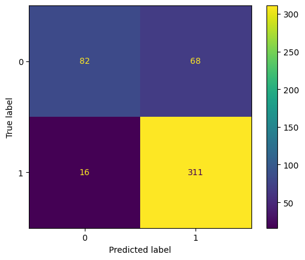

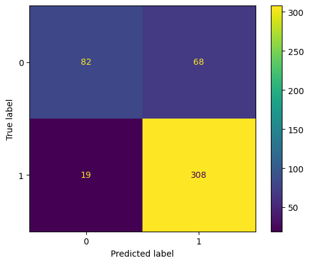

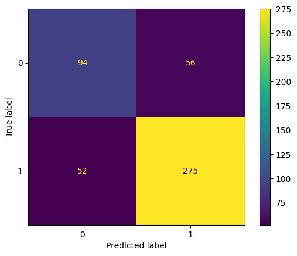

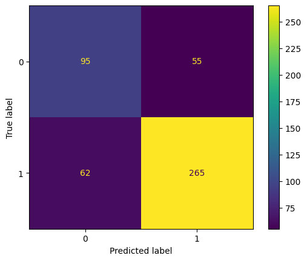

```python
best_model_label_encoded_sm_rf = random_search_label_encoded_sm_rf.best_estimator_
best_model_onehot_sm_rf = random_search_onehot_sm_rf.best_estimator_
best_model_onehot_rf = random_search_onehot_rf.best_estimator_
best_model_label_encoded_rf = random_search_label_encoded_rf.best_estimator_


Y_test_onehot_predict_rf = best_model_onehot_rf.predict(X_test_onehot)
Y_test_label_encoded_predict_rf = best_model_label_encoded_rf.predict(X_test_label_encoded)
Y_test_onehot_predict_sm_rf = best_model_onehot_sm_rf.predict(X_test_onehot)
Y_test_label_encoded_predict_sm_rf = best_model_label_encoded_sm_rf.predict(X_test_label_encoded)


ConfusionMatrixDisplay(confusion_matrix(Y_test_onehot, Y_test_onehot_predict_rf)).plot()
ConfusionMatrixDisplay(confusion_matrix(Y_test_label_encoded, Y_test_label_encoded_predict_rf)).plot()
ConfusionMatrixDisplay(confusion_matrix(Y_test_onehot, Y_test_onehot_predict_sm_rf)).plot()
ConfusionMatrixDisplay(confusion_matrix(Y_test_label_encoded, Y_test_label_encoded_predict_sm_rf)).plot()
```

```python
# with recall
print(classification_report(Y_test_onehot, Y_test_onehot_predict_rf))
print(classification_report(Y_test_label_encoded, Y_test_label_encoded_predict_rf))
print(classification_report(Y_test_onehot, Y_test_onehot_predict_sm_rf))
print(classification_report(Y_test_label_encoded, Y_test_label_encoded_predict_sm_rf))
```

[output not shown]

```python
# with f1
print(classification_report(Y_test_onehot, Y_test_onehot_predict_rf))
print(classification_report(Y_test_label_encoded, Y_test_label_encoded_predict_rf))
print(classification_report(Y_test_onehot, Y_test_onehot_predict_sm_rf))
print(classification_report(Y_test_label_encoded, Y_test_label_encoded_predict_sm_rf))
```

```
              precision    recall  f1-score   support

           0       0.84      0.55      0.66       150
           1       0.82      0.95      0.88       327

    accuracy                           0.82       477
   macro avg       0.83      0.75      0.77       477
weighted avg       0.83      0.82      0.81       477

              precision    recall  f1-score   support

           0       0.81      0.55      0.65       150
           1       0.82      0.94      0.88       327

    accuracy                           0.82       477
   macro avg       0.82      0.74      0.76       477
weighted avg       0.82      0.82      0.81       477

              precision    recall  f1-score   support

           0       0.64      0.63      0.64       150
           1       0.83      0.84      0.84       327

    accuracy                           0.77       477
   macro avg       0.74      0.73      0.74       477
weighted avg       0.77      0.77      0.77       477

              precision    recall  f1-score   support

           0       0.61      0.63      0.62       150
           1       0.83      0.81      0.82       327

    accuracy                           0.75       477
   macro avg       0.72      0.72      0.72       477
weighted avg       0.76      0.75      0.76       477
```

```python
Y_train_onehot_predict_rf = best_model_onehot_rf.predict(X_train_onehot)
Y_train_label_encoded_predict_rf = best_model_label_encoded_rf.predict(X_train_label_encoded)
Y_train_onehot_predict_sm_rf = best_model_onehot_sm_rf.predict(X_train_onehot)
Y_train_label_encoded_predict_sm_rf = best_model_label_encoded_sm_rf.predict(X_train_label_encoded)
```

```python
# Accuracy
print(f"Train Accuracy: {accuracy_score(Y_train_onehot, Y_train_onehot_predict_sm_rf):.4f}")
print(f"Test Accuracy: {accuracy_score(Y_test_onehot, Y_test_onehot_predict_sm_rf):.4f}")
print('*******************************************************')

# Precision
print(f"Train Precision: {precision_score(Y_train_onehot, Y_train_onehot_predict_sm_rf, average='weighted', zero_division=0):.4f}")
print(f"Test Precision: {precision_score(Y_test_onehot, Y_test_onehot_predict_sm_rf):.4f}")
print('*******************************************************')

# Recall
print(f"Train Recall: {recall_score(Y_train_onehot, Y_train_onehot_predict_sm_rf, average='weighted'):.4f}")
print(f"Test Recall: {recall_score(Y_test_onehot, Y_test_onehot_predict_sm_rf):.4f}")
print('*******************************************************')

# F1-score
print(f"Train F1-score: {f1_score(Y_train_onehot, Y_train_onehot_predict_sm_rf, average='weighted'):.4f}")
print(f"Test F1-score: {f1_score(Y_test_onehot, Y_test_onehot_predict_sm_rf):.4f}")
print('*******************************************************')
```

[output not shown]